# NYC Uber Pickup Analysis (2014)

## Project Overview

This project presents a comprehensive data analysis of Uber pick-up patterns in New York City for the year 2014. The primary goal is to uncover hidden insights regarding travel demand, identify key temporal and spatial trends, and evaluate Uber's market position against other For-Hire Vehicle (FHV) companies.

## Key Highlights

- **Advanced Data Processing:** Performed large-scale data cleaning and harmonization of fragmented raw datasets.
- **Memory Optimization:** Utilized vectorization and memory-efficient data handling techniques to process millions of records seamlessly.
- **Geospatial & Temporal Analysis:** Visualized pick-up hotspots and analyzed demand spikes across different times of the day and year.
- **Market Insights:** Conducted a comparative analysis of Uber's market share relative to other NYC transportation services.

## Technologies Used

- **Languages:** Python
- **Data Manipulation:** Pandas, NumPy
- **Visualization:** Plotly (Interactive Charts), Seaborn, Matplotlib
- **Geospatial:** GeoPandas, Geopy
- **Utilities:** Scipy, Garbage Collector (gc)

## Project Structure

- `uber_analysis.ipynb`: The main notebook containing the full analysis, from data ingestion to final visualization.
- `data/`: Directory containing the source datasets (Note: Ensure the datasets are placed here for the notebook to function correctly).

## Key Findings

- **Demand Patterns:** Identified clear peak hours and days where Uber demand significantly outpaced traditional services.
- **Spatial Hotspots:** Mapped high-density pickup zones across NYC, providing insights into urban mobility needs.
- **Market Dominance:** Visualized the competitive landscape of the 2014 NYC FHV market.

## How to Run

1. Clone this repository: `git clone [your-repository-url]`
2. Install the necessary libraries: `pip install pandas numpy geopandas plotly geopy`
3. Launch the Jupyter Notebook: `jupyter notebook uber_analysis.ipynb`

## License

This project is for educational and portfolio purposes. Feel free to use and adapt the code.

```python
if os.path.exists('/kaggle/input'):
    data_path = '/kaggle/input/uber-pickup-new-york-city'
else:
    data_path = './data'

print(f"Data path set to: {data_path}")
```

```
Data path set to: ./data
```

```python
import glob
import os
import pandas as pd
import numpy as np
import matplotlib.pyplot as plt
import seaborn as sns
import geopandas as gpd
import urllib.request
import plotly.express as px
import json
import plotly.io as pio
import gc
import scipy.stats
import plotly.graph_objects as go
from plotly.subplots import make_subplots
import time
from geopy.geocoders import Nominatim
from geopy.extra.rate_limiter import RateLimiter
```

```python
data_path = "../data"
```

```python
file_pattern = os.path.join(data_path, "uber-raw-data-*.csv")
all_files = glob.glob(file_pattern)
```

```python
for file_path in all_files:


    preview_df = pd.read_csv(file_path, nrows=0)

    file_name = os.path.basename(file_path)

    print(f" File name: {file_name}")
    print(f" Columns : {list(preview_df.columns)}")
    print("=" * 50)
```

```
 File name: uber-raw-data-janjune-15.csv
 Columns : ['Dispatching_base_num', 'Pickup_date', 'Affiliated_base_num', 'locationID']
==================================================
 File name: uber-raw-data-apr14.csv
 Columns : ['Date/Time', 'Lat', 'Lon', 'Base']
==================================================
 File name: uber-raw-data-aug14.csv
 Columns : ['Date/Time', 'Lat', 'Lon', 'Base']
==================================================
 File name: uber-raw-data-sep14.csv
 Columns : ['Date/Time', 'Lat', 'Lon', 'Base']
==================================================
 File name: uber-raw-data-jul14.csv
 Columns : ['Date/Time', 'Lat', 'Lon', 'Base']
==================================================
 File name: uber-raw-data-jun14.csv
 Columns : ['Date/Time', 'Lat', 'Lon', 'Base']
==================================================
 File name: uber-raw-data-may14.csv
 Columns : ['Date/Time', 'Lat', 'Lon', 'Base']
==================================================
```

```python
all_dfs = []

print(" Data Upload and Harmonization Process Has Begun...\n")


for file_path in all_files:
    file_name = os.path.basename(file_path)
    print(f" Processing: {file_name}")


    temp_df = pd.read_csv(file_path)

    # SCHEMA HARMONIZATION LAYER
    if 'Date/Time' in temp_df.columns:
        # Editing for 2014 Files
        temp_df = temp_df.rename(columns={
            'Date/Time': 'Pickup_DateTime',
            'Lat': 'Latitude',
            'Lon': 'Longitude',
            'Base': 'Base_Code'
        })
        # Traceability Flag: We mark this data as a coordinate-based source.
        temp_df['Data_Version'] = '2014_Detailed'

    elif 'Pickup_date' in temp_df.columns:
        # Editing for 2015 Files
        temp_df = temp_df.rename(columns={
            'Pickup_date': 'Pickup_DateTime',
            'Dispatching_base_num': 'Base_Code'
        })
        # Traceability Flag: We label this data as being from a summary source.
        temp_df['Data_Version'] = '2015_Summary'

    # Vectorized Time Transformation (It's faster to do this when the files are small)
    temp_df['Pickup_DateTime'] = pd.to_datetime(temp_df['Pickup_DateTime'])

    # We are adding the edited and stamped DataFrame to our list.
    all_dfs.append(temp_df)

# 2. Step: SMART JOIN (seamless join due to aligned schemas)
print("\nAll files are combined into one massive DataFrame....")
df_uber = pd.concat(all_dfs, ignore_index=True)

# Memory cleaning: We delete the list of DataFrames so that it does not take up unnecessary space
del all_dfs

# 3. Stage: Vectorized Feature Generation and Aggressive Memory Optimization
print("⚡ Time features are being derived and RAM is being optimized....")


df_uber['Pickup_Year'] = df_uber['Pickup_DateTime'].dt.year.astype('int16')
df_uber['Pickup_Month'] = df_uber['Pickup_DateTime'].dt.month.astype('int8')
df_uber['Pickup_Day'] = df_uber['Pickup_DateTime'].dt.day.astype('int8')
df_uber['Pickup_Hour'] = df_uber['Pickup_DateTime'].dt.hour.astype('int8')
df_uber['Pickup_Minute'] = df_uber['Pickup_DateTime'].dt.minute.astype('int8')
df_uber['Pickup_WeekDay'] = df_uber['Pickup_DateTime'].dt.dayofweek.astype('int8')
df_uber['Pickup_isweekend'] = (df_uber['Pickup_DateTime'].dt.dayofweek >= 5).astype('int8')

df_uber['Base_Code'] = df_uber['Base_Code'].astype('category')
df_uber['Data_Version'] = df_uber['Data_Version'].astype('category')

if 'Affiliated_base_num' in df_uber.columns:
    df_uber['Affiliated_base_num'] = df_uber['Affiliated_base_num'].astype('category')

print("\n Operation Completed Successfully! New Dataset Architecture:")
print("-" * 60)
print(df_uber.info(memory_usage='deep'))
```

```
 Data Upload and Harmonization Process Has Begun...

 Processing: uber-raw-data-janjune-15.csv
 Processing: uber-raw-data-apr14.csv
 Processing: uber-raw-data-aug14.csv
 Processing: uber-raw-data-sep14.csv
 Processing: uber-raw-data-jul14.csv
 Processing: uber-raw-data-jun14.csv
 Processing: uber-raw-data-may14.csv

All files are combined into one massive DataFrame....
⚡ Time features are being derived and RAM is being optimized....

 Operation Completed Successfully! New Dataset Architecture:
------------------------------------------------------------
<class 'pandas.core.frame.DataFrame'>
RangeIndex: 18804806 entries, 0 to 18804805
Data columns (total 14 columns):
 #   Column               Dtype
---  ------               -----
 0   Base_Code            category
 1   Pickup_DateTime      datetime64[ns]
 2   Affiliated_base_num  category
 3   locationID           float64
 4   Data_Version         category
 5   Latitude             float64
 6   Longitude            float64
 7   Pickup_Year          int16
 8   Pickup_Month         int8
 9   Pickup_Day           int8
 10  Pickup_Hour          int8
 11  Pickup_Minute        int8
 12  Pickup_WeekDay       int8
 13  Pickup_isweekend     int8
dtypes: category(3), datetime64[ns](1), float64(3), int16(1), int8(6)
memory usage: 789.1 MB
None
```

```python
df_uber.head()
```

|  | Base_Code | Pickup_DateTime | Affiliated_base_num | locationID | Data_Version | Latitude | Longitude | Pickup_Year | Pickup_Month | Pickup_Day | Pickup_Hour | Pickup_Minute | Pickup_WeekDay | Pickup_isweekend |
| --- | --- | --- | --- | --- | --- | --- | --- | --- | --- | --- | --- | --- | --- | --- |
| 0 | B02617 | 2015-05-17 09:47:00 | B02617 | 141.0 | 2015_Summary | NaN | NaN | 2015 | 5 | 17 | 9 | 47 | 6 | 1 |
| 1 | B02617 | 2015-05-17 09:47:00 | B02617 | 65.0 | 2015_Summary | NaN | NaN | 2015 | 5 | 17 | 9 | 47 | 6 | 1 |
| 2 | B02617 | 2015-05-17 09:47:00 | B02617 | 100.0 | 2015_Summary | NaN | NaN | 2015 | 5 | 17 | 9 | 47 | 6 | 1 |
| 3 | B02617 | 2015-05-17 09:47:00 | B02774 | 80.0 | 2015_Summary | NaN | NaN | 2015 | 5 | 17 | 9 | 47 | 6 | 1 |
| 4 | B02617 | 2015-05-17 09:47:00 | B02617 | 90.0 | 2015_Summary | NaN | NaN | 2015 | 5 | 17 | 9 | 47 | 6 | 1 |

```python
df_uber.info(memory_usage='deep')
```

```
<class 'pandas.core.frame.DataFrame'>
RangeIndex: 18804806 entries, 0 to 18804805
Data columns (total 14 columns):
 #   Column               Dtype
---  ------               -----
 0   Base_Code            category
 1   Pickup_DateTime      datetime64[ns]
 2   Affiliated_base_num  category
 3   locationID           float64
 4   Data_Version         category
 5   Latitude             float64
 6   Longitude            float64
 7   Pickup_Year          int16
 8   Pickup_Month         int8
 9   Pickup_Day           int8
 10  Pickup_Hour          int8
 11  Pickup_Minute        int8
 12  Pickup_WeekDay       int8
 13  Pickup_isweekend     int8
dtypes: category(3), datetime64[ns](1), float64(3), int16(1), int8(6)
memory usage: 789.1 MB
```

```python
df_uber['Latitude'] = df_uber['Latitude'].astype('float32')
df_uber['Longitude'] = df_uber['Longitude'].astype('float32')
```

```python
df_uber['Base_Code'].value_counts()
```

```
Base_Code
B02764    6017552
B02682    4697319
B02617    3527378
B02598    2919773
B02765    1152727
B02512     461445
B02835      26622
B02836       1990
Name: count, dtype: int64
```

```python
df_uber['Pickup_DayName'] = df_uber['Pickup_DateTime'].dt.day_name()
```

```python
df_uber.head()
```

|  | Base_Code | Pickup_DateTime | Affiliated_base_num | locationID | Data_Version | Latitude | Longitude | Pickup_Year | Pickup_Month | Pickup_Day | Pickup_Hour | Pickup_Minute | Pickup_WeekDay | Pickup_isweekend | Pickup_DayName |
| --- | --- | --- | --- | --- | --- | --- | --- | --- | --- | --- | --- | --- | --- | --- | --- |
| 0 | B02617 | 2015-05-17 09:47:00 | B02617 | 141.0 | 2015_Summary | NaN | NaN | 2015 | 5 | 17 | 9 | 47 | 6 | 1 | Sunday |
| 1 | B02617 | 2015-05-17 09:47:00 | B02617 | 65.0 | 2015_Summary | NaN | NaN | 2015 | 5 | 17 | 9 | 47 | 6 | 1 | Sunday |
| 2 | B02617 | 2015-05-17 09:47:00 | B02617 | 100.0 | 2015_Summary | NaN | NaN | 2015 | 5 | 17 | 9 | 47 | 6 | 1 | Sunday |
| 3 | B02617 | 2015-05-17 09:47:00 | B02774 | 80.0 | 2015_Summary | NaN | NaN | 2015 | 5 | 17 | 9 | 47 | 6 | 1 | Sunday |
| 4 | B02617 | 2015-05-17 09:47:00 | B02617 | 90.0 | 2015_Summary | NaN | NaN | 2015 | 5 | 17 | 9 | 47 | 6 | 1 | Sunday |

```python
df_uber['Pickup_DayName'] = df_uber['Pickup_DayName'].astype('category')
```

```python
df_uber['Base_Code'].cat.categories
```

```
Index(['B02512', 'B02598', 'B02617', 'B02682', 'B02764', 'B02765', 'B02835',
       'B02836'],
      dtype='object')
```

```python
df_uber['Base_Code'].str.match(r'B\d{5}').all()
```

```
True
```

### Data Enrichment and External Data Integration

To enhance the analytical depth of this project and uncover the root causes behind Uber pickup density in New York City (NYC), the core dataset has been enriched with three critical layers of external data. Instead of relying solely on baseline timestamp and location variables, environmental, temporal, and geospatial factors that directly influence passenger demand have been integrated into the data pipeline:

Through this multi-layered approach, the project moves beyond simply asking "When and where was an Uber requested?" and instead answers, "How did the combination of weather, location, and calendar events actively shape urban passenger flows and pickup volume?"

```python
!pip install holidays
```

```python
import holidays

ny_holidays = holidays.US(state='NY', years=[2014,2015])
```

```python
import pandas as pd
import requests

# 1. We are submitting a request to the free historical weather API with the coordinates of New York Central Park.
url = "https://archive-api.open-meteo.com/v1/archive?latitude=40.7829&longitude=-73.9654&start_date=2014-01-01&end_date=2015-12-31&hourly=temperature_2m,precipitation,rain,snowfall&timezone=America%2FNew_York"
response = requests.get(url).json()

# 2. We directly convert the incoming hourly data into a clean DataFrame.
df_weather = pd.DataFrame(response['hourly'])
df_weather['time'] = pd.to_datetime(df_weather['time'])

# Let's make the column names more understandable.
df_weather.columns = ['Pickup_DateTime', 'Temperature', 'Precipitation', 'Rain', 'Snowfall']

print(df_weather.head())
```

```
      Pickup_DateTime  Temperature  Precipitation  Rain  Snowfall
0 2014-01-01 00:00:00         -3.8            0.0   0.0       0.0
1 2014-01-01 01:00:00         -4.2            0.0   0.0       0.0
2 2014-01-01 02:00:00         -4.6            0.0   0.0       0.0
3 2014-01-01 03:00:00         -4.8            0.0   0.0       0.0
4 2014-01-01 04:00:00         -5.0            0.0   0.0       0.0
```

```python
df_zones = pd.read_csv("https://d37ci6vzurychx.cloudfront.net/misc/taxi+_zone_lookup.csv")
```

```python
df_zones.info()
```

```
<class 'pandas.core.frame.DataFrame'>
RangeIndex: 265 entries, 0 to 264
Data columns (total 4 columns):
 #   Column        Non-Null Count  Dtype
---  ------        --------------  -----
 0   LocationID    265 non-null    int64
 1   Borough       264 non-null    object
 2   Zone          264 non-null    object
 3   service_zone  263 non-null    object
dtypes: int64(1), object(3)
memory usage: 8.4+ KB
```

```python
df_weather.info()
```

```
<class 'pandas.core.frame.DataFrame'>
RangeIndex: 17520 entries, 0 to 17519
Data columns (total 5 columns):
 #   Column           Non-Null Count  Dtype
---  ------           --------------  -----
 0   Pickup_DateTime  17520 non-null  datetime64[ns]
 1   Temperature      17520 non-null  float64
 2   Precipitation    17520 non-null  float64
 3   Rain             17520 non-null  float64
 4   Snowfall         17520 non-null  float64
dtypes: datetime64[ns](1), float64(4)
memory usage: 684.5 KB
```

```python
df_weather['Temperature'] = df_weather['Temperature'].astype('float32')
df_weather['Precipitation'] = df_weather['Precipitation'].astype('float32')
df_weather['Rain'] = df_weather['Rain'].astype('float32')
df_weather['Snowfall'] = df_weather['Snowfall'].astype('float32')

df_zones['Borough'] = df_zones['Borough'].astype('category')
df_zones['Zone'] = df_zones['Zone'].astype('category')
```

```python
df_uber = df_uber.merge(df_zones[['LocationID', 'Borough', 'Zone']], left_on='locationID', right_on='LocationID', how='left').drop(columns=['LocationID'])
```

```python
df_uber['is_holiday'] = df_uber['Pickup_DateTime'].dt.date.isin(ny_holidays).astype(int)
```

```python
df_weather.columns = ['Weather_DateTime', 'Temperature', 'Precipitation', 'Rain', 'Snowfall']
df_weather['Weather_DateTime'] = pd.to_datetime(df_weather['Weather_DateTime'])
```

```python
df_uber['Merge_Hour'] = df_uber['Pickup_DateTime'].dt.floor('h')


df_uber = df_uber.merge(df_weather,
                        left_on='Merge_Hour',
                        right_on='Weather_DateTime',
                        how='left')

df_uber = df_uber.drop(columns=['Merge_Hour'])
```

```python
df_uber.head()
```

|  | Base_Code | Pickup_DateTime | Affiliated_base_num | locationID | Data_Version | Latitude | Longitude | Pickup_Year | Pickup_Month | Pickup_Day | ... | Pickup_isweekend | Pickup_DayName | Borough | Zone | is_holiday | Weather_DateTime | Temperature | Precipitation | Rain | Snowfall |
| --- | --- | --- | --- | --- | --- | --- | --- | --- | --- | --- | --- | --- | --- | --- | --- | --- | --- | --- | --- | --- | --- |
| 0 | B02617 | 2015-05-17 09:47:00 | B02617 | 141.0 | 2015_Summary | NaN | NaN | 2015 | 5 | 17 | ... | 1 | Sunday | Manhattan | Lenox Hill West | 0 | 2015-05-17 09:00:00 | 21.200001 | 0.0 | 0.0 | 0.0 |
| 1 | B02617 | 2015-05-17 09:47:00 | B02617 | 65.0 | 2015_Summary | NaN | NaN | 2015 | 5 | 17 | ... | 1 | Sunday | Brooklyn | Downtown Brooklyn/MetroTech | 0 | 2015-05-17 09:00:00 | 21.200001 | 0.0 | 0.0 | 0.0 |
| 2 | B02617 | 2015-05-17 09:47:00 | B02617 | 100.0 | 2015_Summary | NaN | NaN | 2015 | 5 | 17 | ... | 1 | Sunday | Manhattan | Garment District | 0 | 2015-05-17 09:00:00 | 21.200001 | 0.0 | 0.0 | 0.0 |
| 3 | B02617 | 2015-05-17 09:47:00 | B02774 | 80.0 | 2015_Summary | NaN | NaN | 2015 | 5 | 17 | ... | 1 | Sunday | Brooklyn | East Williamsburg | 0 | 2015-05-17 09:00:00 | 21.200001 | 0.0 | 0.0 | 0.0 |
| 4 | B02617 | 2015-05-17 09:47:00 | B02617 | 90.0 | 2015_Summary | NaN | NaN | 2015 | 5 | 17 | ... | 1 | Sunday | Manhattan | Flatiron | 0 | 2015-05-17 09:00:00 | 21.200001 | 0.0 | 0.0 | 0.0 |

5 rows × 23 columns

```python
df_uber['is_holiday'].value_counts()
```

```
is_holiday
0    18345934
1      458872
Name: count, dtype: int64
```

```python
df_uber['Borough'] = df_uber['Borough'].astype('category')
```

```python
df_uber['Zone'] = df_uber['Zone'].astype('category')
```

```python
df_uber['is_holiday'] = df_uber['is_holiday'].astype('int8')
df_uber['Temperature'] = df_uber['Temperature'].astype('float32')
df_uber['Precipitation'] = df_uber['Precipitation'].astype('float32')
df_uber['Rain'] = df_uber['Rain'].astype('float32')
df_uber['Snowfall'] = df_uber['Snowfall'].astype('float32')
```

```python
df_uber['Borough'] = df_uber['Borough'].cat.add_categories('2014 Data (No Borough Info)')
df_uber['Zone'] = df_uber['Zone'].cat.add_categories('2014 Data (No Zone Info)')
```

```python
df_uber['Borough'] = df_uber['Borough'].fillna('2014 Data (No Borough Info)')
df_uber['Zone'] = df_uber['Zone'].fillna('2014 Data (No Zone Info)')
```

```python
df_uber.isnull().sum()
```

```
Base_Code                     0
Pickup_DateTime               0
Affiliated_base_num     4696522
locationID              4534327
Data_Version                  0
Latitude               14270479
Longitude              14270479
Pickup_Year                   0
Pickup_Month                  0
Pickup_Day                    0
Pickup_Hour                   0
Pickup_Minute                 0
Pickup_WeekDay                0
Pickup_isweekend              0
Pickup_DayName                0
Borough                       0
Zone                          0
is_holiday                    0
Weather_DateTime              0
Temperature                   0
Precipitation                 0
Rain                          0
Snowfall                      0
dtype: int64
```

```python
df_geo_analysis = df_uber[df_uber['Latitude'].notna()]
```

```python
bins = [-1,5,12,17,21,24]
labels = ['Early Morning/Night','Morning','Afternoon','Evening','Late Night']

df_uber['Time_of_Day'] = pd.cut(df_uber['Pickup_Hour'], bins=bins, labels=labels).astype('category')
```

```python
df_uber.columns
```

```
Index(['Base_Code', 'Pickup_DateTime', 'Affiliated_base_num', 'locationID',
       'Data_Version', 'Latitude', 'Longitude', 'Pickup_Year', 'Pickup_Month',
       'Pickup_Day', 'Pickup_Hour', 'Pickup_Minute', 'Pickup_WeekDay',
       'Pickup_isweekend', 'Pickup_DayName', 'Borough', 'Zone', 'is_holiday',
       'Weather_DateTime', 'Temperature', 'Precipitation', 'Rain', 'Snowfall',
       'Time_of_Day'],
      dtype='object')
```

```python
df_hourly_demand = df_uber.groupby(['Pickup_Year', 'Pickup_Month', 'Pickup_Day', 'Pickup_Hour']).size().reset_index(name='Total_Rides')

Q1 = df_hourly_demand['Total_Rides'].quantile(0.25)
Q3 = df_hourly_demand['Total_Rides'].quantile(0.75)
IQR = Q3 - Q1

lower_bound = Q1 - 1.5 * IQR
upper_bound = Q3 + 1.5 * IQR

print('--- Hourly Uber Request Outlier Limits ---')
print(f'Lower Limit (Very Low Demand): {lower_bound:.0f} trips')
print(f'Upper Limit (Extreme Demand Spikes) : {upper_bound:.0f} trips')
```

```
--- Hourly Uber Request Outlier Limits ---
Lower Limit (Very Low Demand): -2718 trips
Upper Limit (Extreme Demand Spikes) : 6710 trips
```

```python
df_upper_bound = df_hourly_demand[df_hourly_demand['Total_Rides'] > 6710]

print(df_upper_bound.shape)
```

```
(181, 5)
```

```python
df_upper_bound
```

|  | Pickup_Year | Pickup_Month | Pickup_Day | Pickup_Hour | Total_Rides |
| --- | --- | --- | --- | --- | --- |
| 4393 | 2015 | 1 | 1 | 2 | 7171 |
| 5097 | 2015 | 1 | 30 | 19 | 7247 |
| 5098 | 2015 | 1 | 30 | 20 | 7117 |
| 5100 | 2015 | 1 | 30 | 22 | 6858 |
| 5101 | 2015 | 1 | 30 | 23 | 6722 |
| ... | ... | ... | ... | ... | ... |
| 8649 | 2015 | 6 | 27 | 20 | 9783 |
| 8650 | 2015 | 6 | 27 | 21 | 10575 |
| 8651 | 2015 | 6 | 27 | 22 | 10647 |
| 8652 | 2015 | 6 | 27 | 23 | 10364 |
| 8653 | 2015 | 6 | 28 | 0 | 8980 |

181 rows × 5 columns

```python
df_hourly_demand.head(10)
```

|  | Pickup_Year | Pickup_Month | Pickup_Day | Pickup_Hour | Total_Rides |
| --- | --- | --- | --- | --- | --- |
| 0 | 2014 | 4 | 1 | 0 | 138 |
| 1 | 2014 | 4 | 1 | 1 | 66 |
| 2 | 2014 | 4 | 1 | 2 | 53 |
| 3 | 2014 | 4 | 1 | 3 | 93 |
| 4 | 2014 | 4 | 1 | 4 | 166 |
| 5 | 2014 | 4 | 1 | 5 | 333 |
| 6 | 2014 | 4 | 1 | 6 | 722 |
| 7 | 2014 | 4 | 1 | 7 | 1001 |
| 8 | 2014 | 4 | 1 | 8 | 780 |
| 9 | 2014 | 4 | 1 | 9 | 532 |

```python
df_hourly_weather = df_uber.groupby([
    'Pickup_Year',
    'Pickup_Month',
    'Pickup_Day',
    'Pickup_Hour'
])[['Temperature', 'Precipitation', 'Rain', 'Snowfall', 'is_holiday']].mean().reset_index()
```

```python
df_hourly_weather.head()
```

|  | Pickup_Year | Pickup_Month | Pickup_Day | Pickup_Hour | Temperature | Precipitation | Rain | Snowfall | is_holiday |
| --- | --- | --- | --- | --- | --- | --- | --- | --- | --- |
| 0 | 2014 | 4 | 1 | 0 | 3.4 | 0.0 | 0.0 | 0.0 | 0.0 |
| 1 | 2014 | 4 | 1 | 1 | 2.7 | 0.0 | 0.0 | 0.0 | 0.0 |
| 2 | 2014 | 4 | 1 | 2 | 2.0 | 0.0 | 0.0 | 0.0 | 0.0 |
| 3 | 2014 | 4 | 1 | 3 | 1.4 | 0.0 | 0.0 | 0.0 | 0.0 |
| 4 | 2014 | 4 | 1 | 4 | 0.7 | 0.0 | 0.0 | 0.0 | 0.0 |

```python
df_hourly_merged = pd.merge(
    df_hourly_demand,
    df_hourly_weather,
    on=['Pickup_Year', 'Pickup_Month', 'Pickup_Day', 'Pickup_Hour'],
    how='left'
)
```

```python
df_hourly_merged.head()
```

|  | Pickup_Year | Pickup_Month | Pickup_Day | Pickup_Hour | Total_Rides | Temperature | Precipitation | Rain | Snowfall | is_holiday |
| --- | --- | --- | --- | --- | --- | --- | --- | --- | --- | --- |
| 0 | 2014 | 4 | 1 | 0 | 138 | 3.4 | 0.0 | 0.0 | 0.0 | 0.0 |
| 1 | 2014 | 4 | 1 | 1 | 66 | 2.7 | 0.0 | 0.0 | 0.0 | 0.0 |
| 2 | 2014 | 4 | 1 | 2 | 53 | 2.0 | 0.0 | 0.0 | 0.0 | 0.0 |
| 3 | 2014 | 4 | 1 | 3 | 93 | 1.4 | 0.0 | 0.0 | 0.0 | 0.0 |
| 4 | 2014 | 4 | 1 | 4 | 166 | 0.7 | 0.0 | 0.0 | 0.0 | 0.0 |

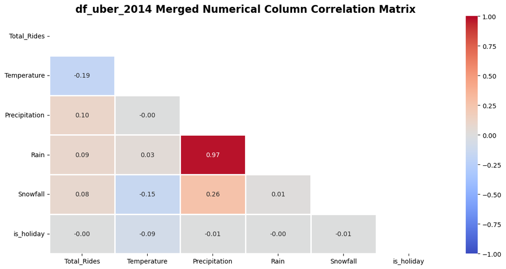

```python
target_cols = ['Total_Rides', 'Temperature', 'Precipitation', 'Rain', 'Snowfall', 'is_holiday']
correlation_matrix = df_hourly_merged[target_cols].corr()


mask = np.triu(np.ones_like(correlation_matrix, dtype=bool))

plt.figure(figsize=(12, 6))

sns.heatmap(correlation_matrix,
            mask=mask,
            annot=True,
            cmap='coolwarm',
            fmt='.2f',
            linewidths=0.8,
            vmin=-1,
            vmax=1)

plt.title('df_uber_2014 Merged Numerical Column Correlation Matrix', fontsize=16, fontweight='bold')
plt.tight_layout()
plt.show()
```

```python
df_extreme_days = df_hourly_merged[df_hourly_merged['Total_Rides'] > 6710]
```

```python
print(df_extreme_days.shape)
df_extreme_days.head()
```

```
(181, 10)
```

|  | Pickup_Year | Pickup_Month | Pickup_Day | Pickup_Hour | Total_Rides | Temperature | Precipitation | Rain | Snowfall | is_holiday |
| --- | --- | --- | --- | --- | --- | --- | --- | --- | --- | --- |
| 4393 | 2015 | 1 | 1 | 2 | 7171 | -4.1 | 0.0 | 0.0 | 0.0 | 1.0 |
| 5097 | 2015 | 1 | 30 | 19 | 7247 | -3.5 | 0.0 | 0.0 | 0.0 | 0.0 |
| 5098 | 2015 | 1 | 30 | 20 | 7117 | -5.6 | 0.0 | 0.0 | 0.0 | 0.0 |
| 5100 | 2015 | 1 | 30 | 22 | 6858 | -8.6 | 0.0 | 0.0 | 0.0 | 0.0 |
| 5101 | 2015 | 1 | 30 | 23 | 6722 | -9.6 | 0.0 | 0.0 | 0.0 | 0.0 |

```python
df_extreme_days['is_holiday'].value_counts()
```

```
is_holiday
0.0    180
1.0      1
Name: count, dtype: int64
```

```python
print(f"Rain Mean: {df_extreme_days['Rain'].mean()}")
print(f"Temperature Mean: {df_extreme_days['Temperature'].mean()}")
print(f"Precipitation Mean: {df_extreme_days['Precipitation'].mean()}")
print(f"Snowfall Mean: {df_extreme_days['Snowfall'].mean()}")
```

```
Rain Mean: 0.35138121247291565
Temperature Mean: 9.291160583496094
Precipitation Mean: 0.42154696583747864
Snowfall Mean: 0.049502767622470856
```

```python
weather_cols = ['Temperature', 'Precipitation', 'Rain', 'Snowfall']

print("--- 1-YEAR AVERAGES ---")
print(df_hourly_merged[weather_cols].mean())

print("--- AVERAGES OF 2 EXTREME DAYS (181 LINES) ---")
print(df_extreme_days[weather_cols].mean())
```

```
--- 1-YEAR AVERAGES ---
Temperature      12.511621
Precipitation     0.111026
Rain              0.097765
Snowfall          0.009628
dtype: float32
--- AVERAGES OF 2 EXTREME DAYS (181 LINES) ---
Temperature      9.291161
Precipitation    0.421547
Rain             0.351381
Snowfall         0.049503
dtype: float32
```

```python
df_extreme_days.sort_values(by='Total_Rides', ascending=False).head(10)
```

|  | Pickup_Year | Pickup_Month | Pickup_Day | Pickup_Hour | Total_Rides | Temperature | Precipitation | Rain | Snowfall | is_holiday |
| --- | --- | --- | --- | --- | --- | --- | --- | --- | --- | --- |
| 8651 | 2015 | 6 | 27 | 22 | 10647 | 16.799999 | 6.7 | 6.7 | 0.0 | 0.0 |
| 8650 | 2015 | 6 | 27 | 21 | 10575 | 16.600000 | 5.3 | 5.3 | 0.0 | 0.0 |
| 8652 | 2015 | 6 | 27 | 23 | 10364 | 16.900000 | 9.1 | 9.1 | 0.0 | 0.0 |
| 7643 | 2015 | 5 | 16 | 22 | 10191 | 19.200001 | 1.2 | 1.2 | 0.0 | 0.0 |
| 8648 | 2015 | 6 | 27 | 19 | 10088 | 16.799999 | 4.0 | 4.0 | 0.0 | 0.0 |
| 8649 | 2015 | 6 | 27 | 20 | 9783 | 16.900000 | 5.5 | 5.5 | 0.0 | 0.0 |
| 7642 | 2015 | 5 | 16 | 21 | 9596 | 19.600000 | 0.4 | 0.4 | 0.0 | 0.0 |
| 7644 | 2015 | 5 | 16 | 23 | 9380 | 19.299999 | 2.3 | 2.3 | 0.0 | 0.0 |
| 8647 | 2015 | 6 | 27 | 18 | 9313 | 16.900000 | 2.4 | 2.4 | 0.0 | 0.0 |
| 7641 | 2015 | 5 | 16 | 20 | 9195 | 20.100000 | 0.0 | 0.0 | 0.0 | 0.0 |

"The Pearson Correlation Matrix applied to the entire dataset indicated no significant relationship between precipitation (0.10) and demand. This is attributed to the 'Zero-Inflation' effect caused by the predominantly non-precipitating (zero-value) days in New York City. However, when the 181 extreme demand hours identified via IQR were isolated and compared to the baseline (overall average), it was revealed that rainfall was 3.6 times higher and snowfall was 5.1 times higher during these peak hours. This proves that although weather conditions do not shift the general trend, they act as a direct trigger for extreme demand fluctuations (outliers)."

```python
pip install geopandas shapely
```

```python
url = "https://data.cityofnewyork.us/api/geospatial/8meu-9t5y?method=export&format=GeoJSON"
output_path = "../data/NYC_Taxi_Zones_Clean.geojson"
```

```python
req = urllib.request.Request(
    url,
    headers={'User-Agent': 'Mozilla/5.0 (Macintosh; Intel Mac OS X 10_15_7)'}
)

with urllib.request.urlopen(req) as response:
    data = response.read()
    with open(output_path, 'wb') as f:
        f.write(data)
```

```python
gdf_zones = gpd.read_file(output_path)
print(f"📊 Total Number of Regions: {len(gdf_zones)}")
```

```
📊 Total Number of Regions: 263
```

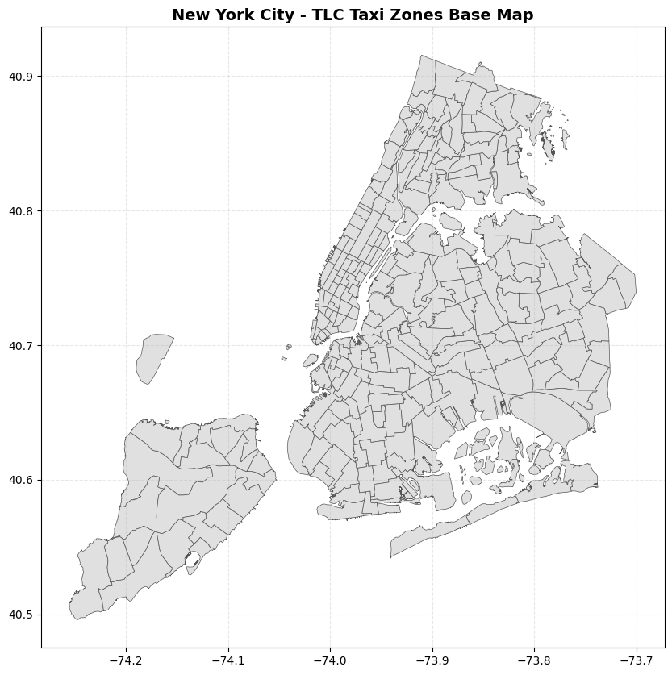

```python
fig, ax = plt.subplots(figsize=(12, 10))
gdf_zones.plot(ax=ax, color='#e0e0e0', edgecolor='#555555', linewidth=0.5)
ax.set_title("New York City - TLC Taxi Zones Base Map", fontsize=14, fontweight='bold')
ax.grid(True, linestyle='--', alpha=0.3)
plt.show()
```

```python
gdf_zones['locationid'].value_counts()
```

```
locationid
103    3
56     2
1      1
176    1
181    1
      ..
94     1
95     1
96     1
97     1
263    1
Name: count, Length: 260, dtype: int64
```

```python
gdf_zones.head()
```

|  | shape_area | locationid | shape_leng | zone | borough | geometry |
| --- | --- | --- | --- | --- | --- | --- |
| 0 | 0.0007823067885 | 1 | 0.116357453189 | Newark Airport | EWR | MULTIPOLYGON (((-74.18445 40.695, -74.18449 40... |
| 1 | 0.00486634037837 | 2 | 0.43346966679 | Jamaica Bay | Queens | MULTIPOLYGON (((-73.82338 40.63899, -73.82277 ... |
| 2 | 0.000314414156821 | 3 | 0.0843411059012 | Allerton/Pelham Gardens | Bronx | MULTIPOLYGON (((-73.84793 40.87134, -73.84725 ... |
| 3 | 0.000111871946192 | 4 | 0.0435665270921 | Alphabet City | Manhattan | MULTIPOLYGON (((-73.97177 40.72582, -73.97179 ... |
| 4 | 0.000497957489363 | 5 | 0.0921464898574 | Arden Heights | Staten Island | MULTIPOLYGON (((-74.17422 40.56257, -74.17349 ... |

```python
df_uber_2015 = df_uber[df_uber['locationID'].notna()].copy()
df_uber_2014 = df_uber[df_uber['locationID'].isna()].copy()

df_uber_2015 = df_uber_2015.drop(columns=['Latitude', 'Longitude'])
df_uber_2014 = df_uber_2014.drop(columns=['locationID', 'Affiliated_base_num'])
```

```python
df_uber_2015['locationID'] = df_uber_2015['locationID'].astype('int')
```

```python
df_uber_2015_summary = df_uber_2015.groupby('locationID').agg(
    total_pickup=('Base_Code','count')
).reset_index()

print(f"2015: {df_uber_2015_summary['total_pickup']}")
```

```
2015: 0         105
1           8
2        3684
3       89319
4          26
        ...
257     67904
258    108338
259    133630
260         7
261      6257
Name: total_pickup, Length: 262, dtype: int64
```

```python
gdf_zones = gdf_zones.to_crs(epsg=4326)
```

```python
df_uber_2014_summary = gpd.GeoDataFrame(
    df_uber_2014,
    geometry=gpd.points_from_xy(df_uber_2014['Longitude'], df_uber_2014['Latitude']),
    crs='EPSG:4326'
)
```

```python
df_uber_2014_with_zones = gpd.sjoin(
    df_uber_2014_summary,
    gdf_zones[['locationid', 'geometry']],
    how='inner',
    predicate='within'
)
```

```python
df_uber_2014_summary_final = df_uber_2014_with_zones.groupby('locationid').size().reset_index(name='total_pickup_2014')

df_uber_2014_summary_final = df_uber_2014_summary_final.rename(columns={'locationid': 'locationID'})
```

```python
df_uber_2014_summary_final['locationID'] = df_uber_2014_summary_final['locationID'].astype(int)
df_uber_2015_summary['locationID'] = df_uber_2015_summary['locationID'].astype(int)
```

```python
df_uber_2015_summary = df_uber_2015_summary.rename(columns={'total_pickup': 'total_pickup_2015'})

df_2014_2015_total_counts = pd.merge(
    df_uber_2014_summary_final,
    df_uber_2015_summary,
    on='locationID',
    how='outer'
)


df_2014_2015_total_counts['total_pickup_2014'] = df_2014_2015_total_counts['total_pickup_2014'].fillna(0)
df_2014_2015_total_counts['total_pickup_2015'] = df_2014_2015_total_counts['total_pickup_2015'].fillna(0)

df_2014_2015_total_counts['Grand_Total_Pickup'] = df_2014_2015_total_counts['total_pickup_2014'] + df_2014_2015_total_counts['total_pickup_2015']


df_2014_2015_total_counts = df_2014_2015_total_counts.sort_values(by='Grand_Total_Pickup', ascending=False).reset_index(drop=True)

print("--- Comprehensive Merged Dataset (Top 5 Zones) ---")
print(df_2014_2015_total_counts.head())
```

```
--- Comprehensive Merged Dataset (Top 5 Zones) ---
   locationID  total_pickup_2014  total_pickup_2015  Grand_Total_Pickup
0         161           176783.0           460732.0            637515.0
1         234           147071.0           419045.0            566116.0
2         231           140462.0           420356.0            560818.0
3          79           125929.0           407591.0            533520.0
4         249           110939.0           323989.0            434928.0
```

```python
gdf_zones['locationid'] = gdf_zones['locationid'].astype(int)
```

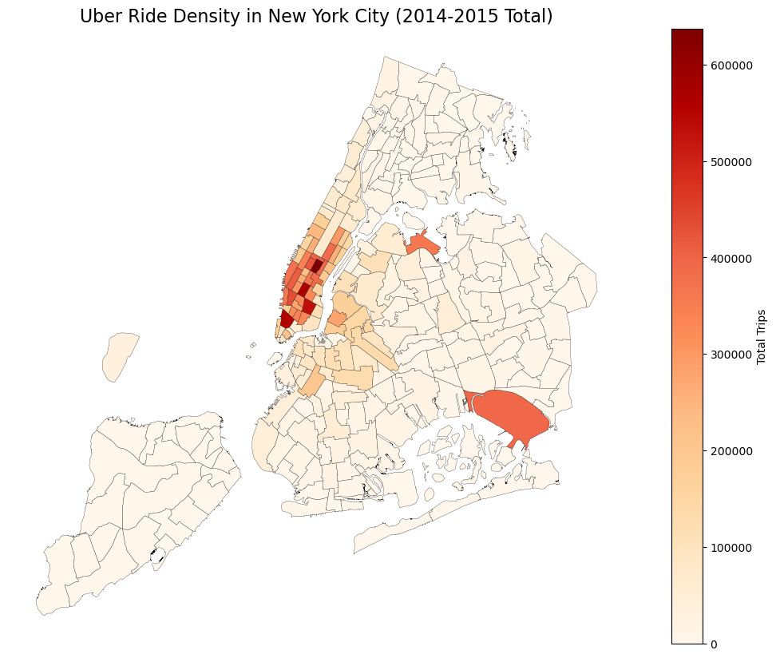

```python
gdf_final = gdf_zones.merge(
    df_2014_2015_total_counts,
    left_on='locationid',
    right_on='locationID',
    how='left'
)

gdf_final['Grand_Total_Pickup'] = gdf_final['Grand_Total_Pickup'].fillna(0)


fig, ax = plt.subplots(figsize=(15, 10))

gdf_final.plot(
    column='Grand_Total_Pickup',
    ax=ax,
    legend=True,
    cmap='OrRd',
    edgecolor='black',
    linewidth=0.2,
    legend_kwds={'label': 'Total Trips'}
)

ax.set_title('Uber Ride Density in New York City (2014-2015 Total)', fontsize=16)
ax.set_axis_off()

plt.show()
```

```python
#%whos DataFrame
```

```python
variables_to_delete = [
    'df_uber_2014', 'df_uber_2014_summary', 'df_uber_2014_summary_final',
    'df_uber_2015', 'df_uber_2015_summary', 'df_upper_bound',
    'df_upper_bound', 'df_hourly_demand', 'df_hourly_merged',
    'df_geo_analysis', 'preview_df', 'temp_df','df_2014_2015_total_counts'
]

for var in variables_to_delete:
    if var in locals():
        del globals()[var]
        print(f"Successfully deleted: {var}")
    else:
        print(f"It doesn't already exist: {var}")

import gc
gc.collect()
```

```
Successfully deleted: df_uber_2014
Successfully deleted: df_uber_2014_summary
Successfully deleted: df_uber_2014_summary_final
Successfully deleted: df_uber_2015
Successfully deleted: df_uber_2015_summary
Successfully deleted: df_upper_bound
It doesn't already exist: df_upper_bound
Successfully deleted: df_hourly_demand
Successfully deleted: df_hourly_merged
Successfully deleted: df_geo_analysis
Successfully deleted: preview_df
Successfully deleted: temp_df
Successfully deleted: df_2014_2015_total_counts
```

```
3341
```

### Cleaning Up the Workspace & Memory Management

Now that the choropleth map is successfully built, it's time to clean up the workspace. While working through the spatial join and aggregations, we created several temporary and duplicate DataFrames.

Since the raw Uber dataset contains millions of rows, keeping these unused tables in memory (RAM) would slow down our notebook. By using the `del` command, we wipe out these intermediate steps. This keeps our project organized, fast, and optimized for the next parts of our analysis.

```python
#%whos DataFrame
```

```python
correlation_matrix.head(100)
```

|  | Total_Rides | Temperature | Precipitation | Rain | Snowfall | is_holiday |
| --- | --- | --- | --- | --- | --- | --- |
| Total_Rides | 1.000000 | -0.185904 | 0.103655 | 0.086509 | 0.082998 | -0.002782 |
| Temperature | -0.185904 | 1.000000 | -0.004869 | 0.031775 | -0.149829 | -0.085692 |
| Precipitation | 0.103655 | -0.004869 | 1.000000 | 0.969086 | 0.259404 | -0.005775 |
| Rain | 0.086509 | 0.031775 | 0.969086 | 1.000000 | 0.013526 | -0.003879 |
| Snowfall | 0.082998 | -0.149829 | 0.259404 | 0.013526 | 1.000000 | -0.007051 |
| is_holiday | -0.002782 | -0.085692 | -0.005775 | -0.003879 | -0.007051 | 1.000000 |

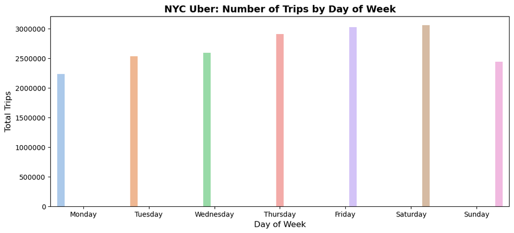

```python
day_order = ['Monday', 'Tuesday', 'Wednesday', 'Thursday', 'Friday', 'Saturday', 'Sunday']

weekly_trip = df_uber.groupby('Pickup_DayName').size().reset_index(name='total trips')

weekly_trip['Pickup_DayName'] = pd.Categorical(
    weekly_trip['Pickup_DayName'],
    categories=day_order,
    ordered=True
)

weekly_trip = weekly_trip.sort_values(by='Pickup_DayName')

plt.figure(figsize=(12, 5))

sns.barplot(data=weekly_trip,
            x='Pickup_DayName',
            y='total trips',
            hue='Pickup_DayName',
            palette='pastel')

plt.gca().get_legend().remove()

plt.ticklabel_format(style='plain', axis='y')
plt.title('NYC Uber: Number of Trips by Day of Week', fontsize=14, fontweight='bold')
plt.xlabel('Day of Week', fontsize=12)
plt.ylabel('Total Trips', fontsize=12)

plt.show()
```

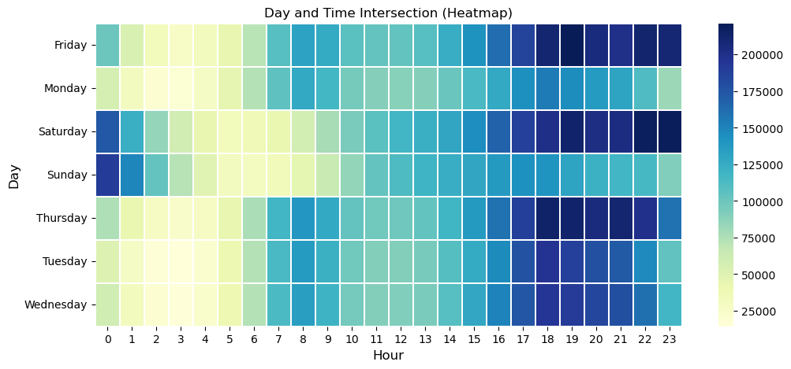

```python
day_hour_counts = df_uber.groupby(['Pickup_DayName','Pickup_Hour']).size().unstack(fill_value=0)

plt.figure(figsize=(12,5))

sns.heatmap(day_hour_counts,
            cmap='YlGnBu',
            linewidths=.1)

plt.title('Day and Time Intersection (Heatmap)')
plt.xlabel('Hour',fontsize=12)
plt.ylabel('Day',fontsize=12)
plt.show()
```

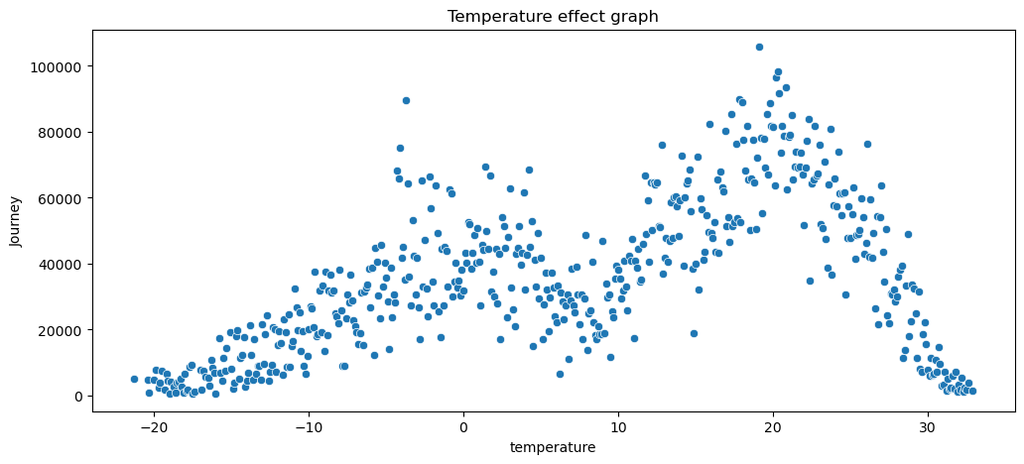

```python
temperature_effect = df_uber.groupby('Temperature').size().reset_index(name='total trips')

temperature_effect = temperature_effect.sort_values(by='Temperature')



plt.figure(figsize=(12,5))

sns.scatterplot(data=temperature_effect,
                x='Temperature',
                y='total trips')

plt.title('Temperature effect graph')
plt.xlabel('temperature')
plt.ylabel('Journey')

plt.show()
```

```python
df_uber.info(memory_usage='deep')
```

```
<class 'pandas.core.frame.DataFrame'>
RangeIndex: 18804806 entries, 0 to 18804805
Data columns (total 24 columns):
 #   Column               Dtype
---  ------               -----
 0   Base_Code            category
 1   Pickup_DateTime      datetime64[ns]
 2   Affiliated_base_num  category
 3   locationID           float64
 4   Data_Version         category
 5   Latitude             float32
 6   Longitude            float32
 7   Pickup_Year          int16
 8   Pickup_Month         int8
 9   Pickup_Day           int8
```

[output cut: 16 more lines]

```python
df_uber['Zone'] = df_uber['Zone'].astype('category')
```

```python
df_uber.columns
```

```
Index(['Base_Code', 'Pickup_DateTime', 'Affiliated_base_num', 'locationID',
       'Data_Version', 'Latitude', 'Longitude', 'Pickup_Year', 'Pickup_Month',
       'Pickup_Day', 'Pickup_Hour', 'Pickup_Minute', 'Pickup_WeekDay',
       'Pickup_isweekend', 'Pickup_DayName', 'Borough', 'Zone', 'is_holiday',
       'Weather_DateTime', 'Temperature', 'Precipitation', 'Rain', 'Snowfall',
       'Time_of_Day'],
      dtype='object')
```

```python
weekly_trip = df_uber.groupby('Pickup_WeekDay').size().reset_index(name='total trips')

weekly_trip = weekly_trip.sort_values(by='Pickup_WeekDay')

fig = px.line(weekly_trip,
              x='Pickup_WeekDay',
              y='total trips',
              title=('Weekly trip numbers'),
              markers=True)


fig.update_layout(
    xaxis_title_font_size=14,
    yaxis_title_font_size=14,
    legend_title_text='Metric',
    hovermode='x unified'
)

fig.show()
```

```python
df_uber['Pickup_WeekDay'].value_counts()
```

```
Pickup_WeekDay
5    3060677
4    3023710
3    2914743
2    2590299
1    2536691
6    2442962
0    2235724
Name: count, dtype: int64
```

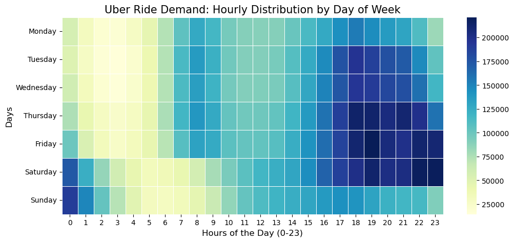

```python
day_order = ['Monday','Tuesday','Wednesday','Thursday','Friday','Saturday','Sunday']

pivot_table  = pd.crosstab(df_uber['Pickup_DayName'], df_uber['Pickup_Hour'])

pivot_table = pivot_table.reindex(day_order)

plt.figure(figsize=(12,5))

ax = sns.heatmap(pivot_table,
                 cmap='YlGnBu',
                 annot=False,
                 linewidths=.5)

plt.title('Uber Ride Demand: Hourly Distribution by Day of Week', fontsize=15)
plt.xlabel('Hours of the Day (0-23)', fontsize=12)
plt.ylabel('Days', fontsize=12)

plt.show()
```

## Strategic Recommendations:

- Dynamic Capacity Management: Implementing surge pricing or incentive-based earning models for drivers during identified peak times (e.g., Friday evenings) could optimize service availability.
- Off-Peak Incentives: To maximize asset utilization, discount structures or promotional campaigns should be targeted during low-demand windows (e.g., early morning hours or mid-day lulls) to stimulate user engagement.
- Data-Informed Scheduling: Operational shifts for the fleet can be adjusted based on the "hourly intensity map" to reduce costs and maintain service quality.

```python
montlhy_trip = df_uber.groupby('Pickup_Month').size().reset_index(name='total trips')

montlhy_trip = montlhy_trip.sort_values(by='Pickup_Month')

fig = px.line(montlhy_trip,
              x='Pickup_Month',
              y='total trips',
              title=('Monthly Trip Numbers'),
              markers=True)


fig.update_layout(
    xaxis_title_font_size=14,
    yaxis_title_font_size=14,
    legend_title_text='Metric',
    hovermode='x unified'
)

fig.show()
```

```python
df_uber.groupby('Pickup_Month')['Pickup_DateTime'].nunique()
```

```
Pickup_Month
1    1244600
2    1324597
3      44555
4      85193
5      88539
6      85767
7      44286
8      44432
9      42907
Name: Pickup_DateTime, dtype: int64
```

```python
df_uber['Pickup_Month'].value_counts()
```

```
Pickup_Month
6    3480739
5    3347988
4    2845353
2    2263620
3    2259773
1    1953801
9    1028136
8     829275
7     796121
Name: count, dtype: int64
```

## The significant drop observed after the six-month mark stems from data interruptions, not a real-world decline in demand. Consequently, these periods should be excluded from the analysis, focusing instead on the first six months or months with higher data coverage for a more reliable comparison.

```python
hourly_trip = df_uber.groupby('Pickup_Hour').size().reset_index(name='total_trips')

hourly_trip = hourly_trip.sort_values(by='Pickup_Hour')

hourly_trip['Rolling_Avg_Hours'] = hourly_trip['total_trips'].rolling(window=7, center=False).mean()

fig = px.line(hourly_trip,
              x='Pickup_Hour',
              y=['total_trips','Rolling_Avg_Hours'],
              title=('Hourly Trip Numbers and Averages'),
              labels={'Pickup_Hour':'Hour','value': 'Number of Trips','variable':'Metric',},
              markers=True)


fig.update_layout(
    xaxis_title_font_size=14,
    yaxis_title_font_size=14,
    legend_title_text='Metric',
    hovermode='x unified'
)

fig.show()
```

```python
df_uber.columns
```

```
Index(['Base_Code', 'Pickup_DateTime', 'Affiliated_base_num', 'locationID',
       'Data_Version', 'Latitude', 'Longitude', 'Pickup_Year', 'Pickup_Month',
       'Pickup_Day', 'Pickup_Hour', 'Pickup_Minute', 'Pickup_WeekDay',
       'Pickup_isweekend', 'Pickup_DayName', 'Borough', 'Zone', 'is_holiday',
       'Weather_DateTime', 'Temperature', 'Precipitation', 'Rain', 'Snowfall',
       'Time_of_Day'],
      dtype='object')
```

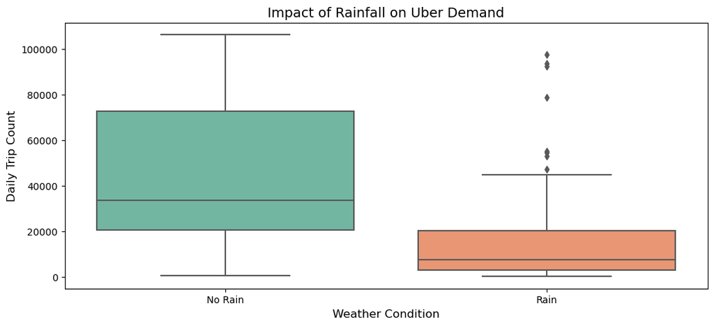

```python
df_uber['Rain_Status'] = df_uber['Rain'].apply(lambda x: 'Rain' if x > 0 else 'No Rain')
rainy_trips = df_uber.groupby([df_uber['Pickup_DateTime'].dt.date, 'Rain_Status']).size().reset_index(name='total trips')
plt.figure(figsize=(12,5))

sns.boxplot(data=rainy_trips,
            x='Rain_Status',
            y='total trips',
            palette='Set2')

plt.title('Impact of Rainfall on Uber Demand', fontsize=14)
plt.xlabel('Weather Condition', fontsize=12)
plt.ylabel('Daily Trip Count', fontsize=12)

plt.show()
```

```python
df_uber['Rain_Status'] = df_uber['Rain_Status'].astype('category')
```

```python
rainy_days = rainy_trips[rainy_trips['Rain_Status'] == 'Rain']

outliers = rainy_days[rainy_days['total trips'] > 80000]
print(outliers)
```

```
    Pickup_DateTime Rain_Status  total trips
464      2015-06-01        Rain        93499
465      2015-06-02        Rain        97592
504      2015-06-27        Rain        92346
```

```python
limit_80k = rainy_days[rainy_days['total trips'] > 80000].shape[0]
limit_70k = rainy_days[rainy_days['total trips'] > 70000].shape[0]
limit_65k = rainy_days[rainy_days['total trips'] > 65000].shape[0]

print(f"Number of points greater than 80,000: {limit_80k}")
print(f"Number of points greater than 70,000: {limit_70k}")
print(f"Number of points greater than 65,000: {limit_65k}")
```

```
Number of points greater than 80,000: 3
Number of points greater than 70,000: 4
Number of points greater than 65,000: 4
```

```python
target_dates = pd.to_datetime(['2015-06-01', '2015-06-02', '2015-06-27']).date


df_subset = df_uber[df_uber['Pickup_DateTime'].dt.date.isin(target_dates)]


hourly_data = df_subset.groupby([df_subset['Pickup_DateTime'].dt.date, 'Pickup_Hour']).size().reset_index(name='trip_count')
hourly_data.columns = ['Date', 'Hour', 'Trip_Count']


hourly_data['Date'] = hourly_data['Date'].astype(str)


fig = px.line(hourly_data,
              x='Hour',
              y='Trip_Count',
              color='Date',
              markers=True,
              title='Hourly Trip Distribution: Outlier Days (June 2015)',
              labels={'Trip_Count': 'Number of Trips', 'Hour': 'Hour of the Day'})

fig.update_layout(hovermode="x unified")
fig.show()
```

```python
df_uber.columns
```

```
Index(['Base_Code', 'Pickup_DateTime', 'Affiliated_base_num', 'locationID',
       'Data_Version', 'Latitude', 'Longitude', 'Pickup_Year', 'Pickup_Month',
       'Pickup_Day', 'Pickup_Hour', 'Pickup_Minute', 'Pickup_WeekDay',
       'Pickup_isweekend', 'Pickup_DayName', 'Borough', 'Zone', 'is_holiday',
       'Weather_DateTime', 'Temperature', 'Precipitation', 'Rain', 'Snowfall',
       'Time_of_Day', 'Rain_Status'],
      dtype='object')
```

```python
df_sample = df_uber.sample(n=100000, random_state=42)

fig = px.density_mapbox(
    df_sample,
    lat='Latitude',
    lon='Longitude',
    radius=1,
    opacity=0.6,
    center=dict(lat=df_uber['Latitude'].mean(), lon=df_uber['Longitude'].mean()),
    zoom=10,
    mapbox_style='carto-darkmatter'
)

fig.update_layout(
    title={
        'text': "New York City Uber Ride Density Analysis",
        'y': 0.95,
        'x': 0.5,
        'xanchor': 'center',
        'yanchor': 'top'
    },
    title_font=dict(size=18, color='white', family="Arial"),
    paper_bgcolor='black',
    coloraxis_showscale=False,
    margin={"r":0,"t":60,"l":0,"b":0}
)

fig.show()
```

```python
df_uber.info(memory_usage='deep')
```

```
<class 'pandas.core.frame.DataFrame'>
RangeIndex: 18804806 entries, 0 to 18804805
Data columns (total 25 columns):
 #   Column               Dtype
---  ------               -----
 0   Base_Code            category
 1   Pickup_DateTime      datetime64[ns]
 2   Affiliated_base_num  category
 3   locationID           float64
 4   Data_Version         category
 5   Latitude             float32
 6   Longitude            float32
 7   Pickup_Year          int16
 8   Pickup_Month         int8
 9   Pickup_Day           int8
```

[output cut: 17 more lines]

```python
file_list = glob.glob('../data/uber-raw-data-*.csv')

print(f"Total number of files: {len(file_list)}")
print("-" * 30)
for file in file_list:
    print(f"File name: {os.path.basename(file)}")
```

```
Total number of files: 7
------------------------------
File name: uber-raw-data-janjune-15.csv
File name: uber-raw-data-apr14.csv
File name: uber-raw-data-aug14.csv
File name: uber-raw-data-sep14.csv
File name: uber-raw-data-jul14.csv
File name: uber-raw-data-jun14.csv
File name: uber-raw-data-may14.csv
```

```python
#%whos DataFrame%whos DataFrame
```

```python
del weekly_trip, montlhy_trip, hourly_trip, hourly_data
del df_sample, df_subset, outliers, rainy_days, rainy_trips
del correlation_matrix, pivot_table, day_hour_counts, temperature_effect

gc.collect()
```

```
23574
```

```python
#%whos DataFrame%whos DataFrame
```

## df_uber_jan_feb_foil

```python
df_foil = pd.read_csv('../data/Uber-Jan-Feb-FOIL.csv')
```

```python
df_foil.head()
```

|  | dispatching_base_number | date | active_vehicles | trips |
| --- | --- | --- | --- | --- |
| 0 | B02512 | 1/1/2015 | 190 | 1132 |
| 1 | B02765 | 1/1/2015 | 225 | 1765 |
| 2 | B02764 | 1/1/2015 | 3427 | 29421 |
| 3 | B02682 | 1/1/2015 | 945 | 7679 |
| 4 | B02617 | 1/1/2015 | 1228 | 9537 |

```python
df_foil.info(memory_usage='deep')
```

```
<class 'pandas.core.frame.DataFrame'>
RangeIndex: 354 entries, 0 to 353
Data columns (total 4 columns):
 #   Column                   Non-Null Count  Dtype
---  ------                   --------------  -----
 0   dispatching_base_number  354 non-null    object
 1   date                     354 non-null    object
 2   active_vehicles          354 non-null    int64
 3   trips                    354 non-null    int64
dtypes: int64(2), object(2)
memory usage: 50.2 KB
```

```python
df_foil.shape
```

```
(354, 4)
```

```python
df_foil['date'] = pd.to_datetime(df_foil['date'], errors='coerce')
```

```python
df_foil['trips'].max()
```

```
45858
```

```python
df_foil['year'] = df_foil['date'].dt.year.astype('int16')
df_foil['month'] = df_foil['date'].dt.month.astype('int8')
df_foil['day'] = df_foil['date'].dt.day.astype('int8')
df_foil['dayofweek'] = df_foil['date'].dt.day_of_week.astype('int8')
df_foil['is_weekend'] = (df_foil['dayofweek'] > 4).astype('int8')


df_foil['dispatching_base_number'] = df_foil['dispatching_base_number'].astype('category')

df_foil['active_vehicles'] = df_foil['active_vehicles'].astype('int16')

df_foil['trips'] = df_foil['trips'].astype('int32')
```

```python
df_foil.info(memory_usage='deep')
```

```
<class 'pandas.core.frame.DataFrame'>
RangeIndex: 354 entries, 0 to 353
Data columns (total 9 columns):
 #   Column                   Non-Null Count  Dtype
---  ------                   --------------  -----
 0   dispatching_base_number  354 non-null    category
 1   date                     354 non-null    datetime64[ns]
 2   active_vehicles          354 non-null    int16
 3   trips                    354 non-null    int32
 4   year                     354 non-null    int16
 5   month                    354 non-null    int8
 6   day                      354 non-null    int8
 7   dayofweek                354 non-null    int8
 8   is_weekend               354 non-null    int8
dtypes: category(1), datetime64[ns](1), int16(2), int32(1), int8(4)
memory usage: 7.9 KB
```

```python
df_foil['dispatching_base_number'].value_counts()
```

```
dispatching_base_number
B02512    59
B02598    59
B02617    59
B02682    59
B02764    59
B02765    59
Name: count, dtype: int64
```

```python
df_foil.head()
```

|  | dispatching_base_number | date | active_vehicles | trips | year | month | day | dayofweek | is_weekend |
| --- | --- | --- | --- | --- | --- | --- | --- | --- | --- |
| 0 | B02512 | 2015-01-01 | 190 | 1132 | 2015 | 1 | 1 | 3 | 0 |
| 1 | B02765 | 2015-01-01 | 225 | 1765 | 2015 | 1 | 1 | 3 | 0 |
| 2 | B02764 | 2015-01-01 | 3427 | 29421 | 2015 | 1 | 1 | 3 | 0 |
| 3 | B02682 | 2015-01-01 | 945 | 7679 | 2015 | 1 | 1 | 3 | 0 |
| 4 | B02617 | 2015-01-01 | 1228 | 9537 | 2015 | 1 | 1 | 3 | 0 |

```python
vehicle_day_efficiency = (
    df_foil.groupby(['dispatching_base_number','day'])
    .agg(total_day=('active_vehicles','sum'),
         total_trips=('trips','sum'))
    .assign(efficiency=lambda x: x['total_trips'] / x['total_day'])
    .sort_values(['dispatching_base_number' ,'day'])
    .reset_index()
)

fig = px.line(vehicle_day_efficiency,
              x='day',
              y='efficiency',
              color='dispatching_base_number',
              title='Vehicle and trip on a daily basis',
              markers=True,
              labels={'day': 'DAY', 'efficiency': 'Efficiency (Trips / Vehicles)'})

fig.update_layout(hovermode="x unified",
                  width=1000,
                  height=500)
fig.show()
```

```python
vehicle_month_efficiency= (
    df_foil.groupby(['dispatching_base_number','month'])
    .agg(total_month=('active_vehicles','sum'),
         total_trips=('trips','sum'))
    .assign(efficiency=lambda x: x['total_trips'] / x['total_month'])
    .sort_values(['dispatching_base_number','month'])
    .reset_index()
)


fig = px.line(vehicle_month_efficiency,
              x='month',
              y='efficiency',
              color='dispatching_base_number',
              markers=True)

fig.update_layout(hovermode="x unified",
                  width=1000,
                  height=500)
fig.show()
```

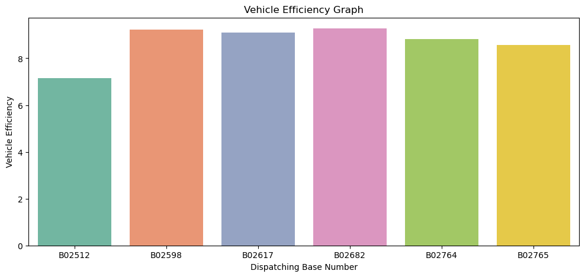

```python
vehicle_efficiency = (
    df_foil.groupby('dispatching_base_number')
    .agg(total_vehicles=('active_vehicles', 'sum'),
         total_trips=('trips', 'sum'))
    .assign(efficiency=lambda x: x['total_trips'] / x['total_vehicles'])
    .reset_index()
)

plt.figure(figsize=(12,5))

sns.barplot(data=vehicle_efficiency,
            x='dispatching_base_number',
            y='efficiency',
            palette='Set2')

plt.title('Vehicle Efficiency Graph')
plt.xlabel('Dispatching Base Number')
plt.ylabel('Vehicle Efficiency')
plt.show()
```

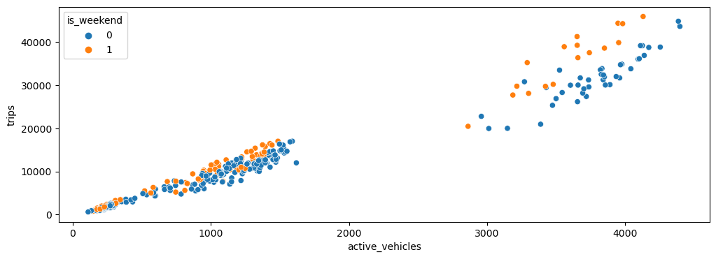

```python
plt.figure(figsize=(12,4))

sns.scatterplot(data=df_foil,
                x='active_vehicles',
                y='trips',
                hue='is_weekend')
```

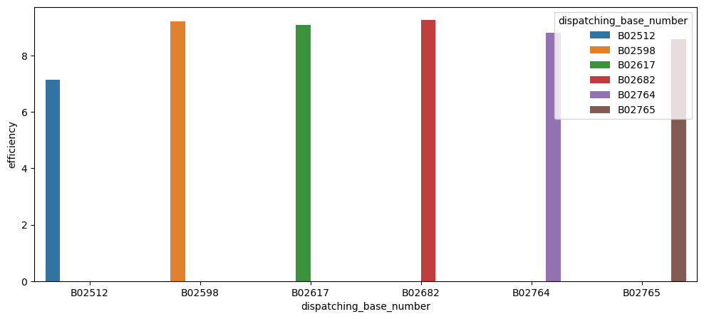

```python
base_trip =(
df_foil.groupby('dispatching_base_number')
.agg(total_vehicles=('active_vehicles','sum'),
     total_trips=('trips','sum'))
.assign(efficiency=lambda x: x['total_trips'] / x['total_vehicles'])
.reset_index()
)

plt.figure(figsize=(12,5))

sns.barplot(data=base_trip,
            x='dispatching_base_number',
            y='efficiency',
            hue='dispatching_base_number',
            )

plt.show()
```

```python
z_score_trips = np.abs(scipy.stats.zscore(df_foil['trips']))

df_foil['is_high_volume'] = (z_score_trips > 3).astype(int)

standard_days = df_foil[df_foil['is_high_volume'] ==0]

peak_days = df_foil[df_foil['is_high_volume'] ==1]

print(f'Standard days: {len(standard_days)}')
print(f'Number of peak days: {len(peak_days)}')
print('-' * 30)
print(f'Standard day average travel {standard_days["trips"].mean():.2f}')
print(f'Average trips on peak days: {peak_days["trips"].mean():.2f}')
```

```
Standard days: 350
Number of peak days: 4
------------------------------
Standard day average travel 11288.93
Average trips on peak days: 44776.00
```

```python
DAY_ORDER = ['Monday', 'Tuesday', 'Wednesday', 'Thursday', 'Friday', 'Saturday', 'Sunday']


outlier_mask = (np.abs(scipy.stats.zscore(df_foil['trips'])) < 3) & \
               (np.abs(scipy.stats.zscore(df_foil['active_vehicles'])) < 3)


daily_summary = (
    df_foil[outlier_mask]
    .assign(
        day_name = lambda x: pd.Categorical(x['date'].dt.day_name(), categories=DAY_ORDER, ordered=True)
    )
    .groupby('day_name', observed=False)
    .agg(
        total_trips=('trips', 'sum'),
        total_active_vehicles=('active_vehicles', 'sum')
    )
    .reset_index()
)

fig = make_subplots(
    rows=1, cols=2,
    subplot_titles=('Total Trips by Day of the Week', 'Total Active Vehicles by Day of the Week')
)

fig.add_trace(
    go.Bar(x=daily_summary['day_name'], y=daily_summary['total_trips'], name='Total Trips', marker_color='lightcoral'),
    row=1, col=1
)

fig.add_trace(
    go.Bar(x=daily_summary['day_name'], y=daily_summary['total_active_vehicles'], name='Total Active Vehicles', marker_color='lightseagreen'),
    row=1, col=2
)

fig.update_layout(
    title_text='Uber Usage and Vehicle Activity by Day of the Week (Jan-Feb 2015)',
    title_x=0.5,
    template='plotly_white'
)

fig.show()
```

## df_fhv_services

```python
data_path = '../data'
target_files = [
    "other-American_B01362.csv", "other-Diplo_B01196.csv", "other-Highclass_B01717.csv",
    "other-Skyline_B00111.csv", "other-Carmel_B00256.csv", "other-Federal_02216.csv",
    "other-Lyft_B02510.csv", "other-Dial7_B00887.csv", "other-Firstclass_B01536.csv", "other-Prestige_B01338.csv"
]

column_mapper = {
    'PICK UP ADDRESS': 'Address', 'PU_Address': 'Address', 'PU_Adress': 'Address',
    'Street_Address': 'Address', 'Street': 'Address', 'PU_Address.1': 'Address',
    'DO_Address': 'Address', 'PuFrom': 'Address',
    'DATE': 'Date', 'Pick Up Date': 'Date',
    'TIME': 'Time', 'time_of_trip': 'Time', 'City_State': 'State', 'City': 'State'
}

all_companies_data = []

for f in target_files:
    path = os.path.join(data_path, f)
    if os.path.exists(path):
        df = pd.read_csv(path, encoding='latin1')
        df.columns = df.columns.str.strip()
        df = df.rename(columns=column_mapper)

        df = df.groupby(df.columns, axis=1).first()


        if 'Date' not in df.columns and 'Time' in df.columns:
            dt_series = pd.to_datetime(df['Time'], errors='coerce')
            df['Date'] = dt_series.dt.date
            df['Time'] = dt_series.dt.time

        df['Company_Source'] = f.split('.')[0]
        all_companies_data.append(df)


if all_companies_data:
    master_df = pd.concat(all_companies_data, ignore_index=True)

    master_df['Date_Time'] = pd.to_datetime(
        master_df['Date'].astype(str) + ' ' + master_df['Time'].astype(str),
        errors='coerce'
    )

    print("--- NEW AND FLAWLESS REPORT ---")
    print("Total number of rows:", len(master_df))
    print("Number of empty Date_Time slots (Error checking):", master_df['Date_Time'].isna().sum())
    print("\n--- Example of the first 5 lines ---")
    print(master_df[['Company_Source', 'Date_Time']].head())
else:
    print("Data could not be read, please check.")
```

[output not shown]

```
--- NEW AND FLAWLESS REPORT ---
Total number of rows: 1676781
Number of empty Date_Time slots (Error checking): 0

--- Example of the first 5 lines ---
          Company_Source           Date_Time
0  other-American_B01362 2014-07-01 00:00:00
1  other-American_B01362 2014-07-01 00:01:00
2  other-American_B01362 2014-07-01 00:01:00
3  other-American_B01362 2014-07-01 00:01:00
4  other-American_B01362 2014-07-01 00:02:00
```

```python
for f in target_files:
    path = os.path.join(data_path, f)

    if os.path.exists(path):
        df = pd.read_csv(path, encoding='latin1')

        print(f"\n>>> File: {f}")
        print(f"Number of columns: {len(df.columns)}")
        print(f"Column names: {list(df.columns)}")

        df.columns = df.columns.str.strip()
```

```
>>> File: other-American_B01362.csv
Number of columns: 6
Column names: ['DATE', 'TIME', 'PICK UP ADDRESS', 'Unnamed: 3', 'Unnamed: 4', 'Unnamed: 5']

>>> File: other-Diplo_B01196.csv
Number of columns: 3
Column names: ['Date', 'Time', 'PU_Address']

>>> File: other-Highclass_B01717.csv
Number of columns: 3
Column names: ['DATE', 'TIME', 'PU_Address']

>>> File: other-Skyline_B00111.csv
Number of columns: 6
Column names: ['Date', 'Time', '    Street_Address ', '    City_State ', 'Unnamed: 4', 'Unnamed: 5']

>>> File: other-Carmel_B00256.csv
Number of columns: 4
Column names: ['Date', 'Time', 'PU_Adress', 'Base_No']

>>> File: other-Federal_02216.csv
Number of columns: 7
Column names: ['Date', 'Time', 'PU_Address', 'DO_Address', 'Routing Details', 'PU_Address.1', 'Status']

>>> File: other-Lyft_B02510.csv
Number of columns: 4
Column names: ['time_of_trip', 'start_lat', 'start_lng', 'Unnamed: 3']

>>> File: other-Dial7_B00887.csv
Number of columns: 6
Column names: ['Date', 'Time', 'State', 'PuFrom', 'Address', 'Street']

>>> File: other-Firstclass_B01536.csv
Number of columns: 3
Column names: ['DATE', 'TIME', 'PICK UP ADDRESS']

>>> File: other-Prestige_B01338.csv
Number of columns: 3
Column names: ['DATE', 'TIME', 'PICK UP ADDRESS']
```

```python
report = master_df.groupby('Company_Source').apply(
    lambda x: pd.Series({'Number of Rows': len(x), 'Number of Columns': len(x.columns)})
)

print("--- COMPANY-BASED DATA SUMMARY ---")
print(report)
```

```
--- COMPANY-BASED DATA SUMMARY ---
                         Number of Rows  Number of Columns
Company_Source
other-American_B01362             91712                 14
other-Carmel_B00256              256519                 14
other-Dial7_B00887               194992                 14
other-Diplo_B01196                98550                 14
other-Federal_02216                 276                 14
other-Firstclass_B01536          166769                 14
other-Highclass_B01717           151925                 14
other-Lyft_B02510                267701                 14
other-Prestige_B01338            320641                 14
other-Skyline_B00111             127696                 14
```

```python
master_df.head()
```

|  | Address | Date | Time | Unnamed: 3 | Unnamed: 4 | Unnamed: 5 | Company_Source | State | Base_No | Routing Details | Status | start_lat | start_lng | Date_Time |
| --- | --- | --- | --- | --- | --- | --- | --- | --- | --- | --- | --- | --- | --- | --- |
| 0 | 874 E 139th St Mott Haven, BX | 7/1/2014 | 12:00:00 AM | None | None | None | other-American_B01362 | NaN | NaN | NaN | NaN | NaN | NaN | 2014-07-01 00:00:00 |
| 1 | 628 E 141st St Mott Haven, BX | 7/1/2014 | 12:01:00 AM | None | None | None | other-American_B01362 | NaN | NaN | NaN | NaN | NaN | NaN | 2014-07-01 00:01:00 |
| 2 | 601 E 156th St South Bronx, BX | 7/1/2014 | 12:01:00 AM | None | None | None | other-American_B01362 | NaN | NaN | NaN | NaN | NaN | NaN | 2014-07-01 00:01:00 |
| 3 | 708 E 138th St Mott Haven, BX | 7/1/2014 | 12:01:00 AM | None | None | None | other-American_B01362 | NaN | NaN | NaN | NaN | NaN | NaN | 2014-07-01 00:01:00 |
| 4 | 700 E 140th St Mott Haven, BX | 7/1/2014 | 12:02:00 AM | None | None | None | other-American_B01362 | NaN | NaN | NaN | NaN | NaN | NaN | 2014-07-01 00:02:00 |

```python
master_df.isnull().sum()
```

```
Address             267701
Date                     0
Time                     0
Unnamed: 3         1675583
Unnamed: 4         1676781
Unnamed: 5         1676781
Company_Source           0
State              1354093
Base_No            1420262
Routing Details    1676505
Status             1676505
start_lat          1409081
start_lng          1409081
Date_Time                0
dtype: int64
```

## Dataset Structural Integrity & Missing Values Documentation

When analyzing this consolidated For-Hire Vehicle (FHV) dataset, you will notice significant missing (`NaN`) values in specific columns. Rather than being a sign of corrupted data ingestion, this sparsity is a **structural characteristic** resulting from different data-logging standards across traditional bases and modern ridesharing platforms.

Here is the strategic breakdown of why these missing values are kept intact:

### 1. The Location Data Dichotomy (Address vs. GPS Coordinates)

- **`Address` (267,701 missing rows):** This exact missing count corresponds directly to the total ride volume of **Lyft**. Traditional car services (e.g., Carmel, Dial7) logged pickup locations as physical street addresses. Lyft, being a modern app-based platform, logs origins exclusively via precise GPS coordinates.
- **`start_lat` & `start_lng` (1,409,081 missing rows):** Conversely, Lyft is the *only* provider that captures geographic coordinates. All other traditional companies lack this telemetry, leaving these columns blank for their respective rows.

### 2. Provider-Specific Administrative Metadata

- **`State` & `Base_No` (High missing rates):** These columns contain administrative metadata (such as TLC license base numbers or localized region codes). These attributes were specific to traditional fleet management systems and were not tracked uniformly across the entire industry.

### Data Modeling Conclusion

Imputing or dropping these `NaN` values would be mathematically flawed. Deleting rows with missing addresses would inadvertently wipe out the entire Lyft market share, while deleting rows with missing coordinates would erase traditional taxi history. Retaining these structural gaps is essential for market-share integrity and multi-modal analysis.

```python
fill_rates = (master_df[['Status', 'Routing Details']].notna().mean() * 100).round(2)

print("--- COLUMN FILL RATES (%) ---")
print(fill_rates.astype(str) + '%')
```

```
--- COLUMN FILL RATES (%) ---
Status             0.02%
Routing Details    0.02%
dtype: object
```

```python
master_df = master_df.drop(columns=['Unnamed: 3', 'Unnamed: 4', 'Unnamed: 5','Status','Routing Details','Date','Time'])
```

```python
master_df.info(memory_usage='deep')
```

```
<class 'pandas.core.frame.DataFrame'>
RangeIndex: 1676781 entries, 0 to 1676780
Data columns (total 7 columns):
 #   Column          Non-Null Count    Dtype
---  ------          --------------    -----
 0   Address         1409080 non-null  object
 1   Company_Source  1676781 non-null  object
 2   State           322688 non-null   object
 3   Base_No         256519 non-null   object
 4   start_lat       267700 non-null   float64
 5   start_lng       267700 non-null   float64
 6   Date_Time       1676781 non-null  datetime64[ns]
dtypes: datetime64[ns](1), float64(2), object(4)
memory usage: 423.8 MB
```

```python
# --- 1. CATEGORY COLUMN OPTIMIZATIONS ---
master_df['Address'] = master_df['Address'].astype('category')
master_df['Company_Source'] = master_df['Company_Source'].astype('category')
master_df['Base_No'] = master_df['Base_No'].astype('category')

# CORRECTION: We perform the space removal (strip) operation BEFORE adding to the category!
master_df['State'] = master_df['State'].astype(str).str.strip().astype('category')


# --- 2. DATE AND TIME FEATURES (VIA DATE_TIME) ---
master_df['Date_Time_Year'] = master_df['Date_Time'].dt.year.astype('int16')
master_df['Date_Time_Month'] = master_df['Date_Time'].dt.month.astype('int8')
master_df['Date_Time_Day'] = master_df['Date_Time'].dt.day.astype('int8')
master_df['Date_Time_Hour'] = master_df['Date_Time'].dt.hour.astype('int8')

master_df['Date_Time_Minute'] = master_df['Date_Time'].dt.minute.astype('int8')
master_df['Date_Time_Day_Name'] = master_df['Date_Time'].dt.day_name().astype('category')
master_df['Date_Time_WeekDay'] = master_df['Date_Time'].dt.dayofweek.astype('int8')
master_df['Date_Time_Isweekend'] = (master_df['Date_Time'].dt.dayofweek >= 5).astype('int8')


print("--- ALL DATA TYPES AND TIME PROPERTIES HAVE BEEN SUCCESSFULLY CORRECTED. ---")
```

```
--- ALL DATA TYPES AND TIME PROPERTIES HAVE BEEN SUCCESSFULLY CORRECTED. ---
```

```python
master_df.info(memory_usage='deep')
```

```
<class 'pandas.core.frame.DataFrame'>
RangeIndex: 1676781 entries, 0 to 1676780
Data columns (total 15 columns):
 #   Column               Non-Null Count    Dtype
---  ------               --------------    -----
 0   Address              1409080 non-null  category
 1   Company_Source       1676781 non-null  category
 2   State                1676781 non-null  category
 3   Base_No              256519 non-null   category
 4   start_lat            267700 non-null   float64
 5   start_lng            267700 non-null   float64
 6   Date_Time            1676781 non-null  datetime64[ns]
 7   Date_Time_Year       1676781 non-null  int16
 8   Date_Time_Month      1676781 non-null  int8
 9   Date_Time_Day        1676781 non-null  int8
 10  Date_Time_Hour       1676781 non-null  int8
 11  Date_Time_Minute     1676781 non-null  int8
 12  Date_Time_Day_Name   1676781 non-null  category
 13  Date_Time_WeekDay    1676781 non-null  int8
 14  Date_Time_Isweekend  1676781 non-null  int8
dtypes: category(5), datetime64[ns](1), float64(2), int16(1), int8(6)
memory usage: 85.9 MB
```

```python
valid_years = master_df['Date_Time_Year'].between(2014, 2015)
valid_hours = master_df['Date_Time_Hour'].between(0,23)
valid_minutes = master_df['Date_Time_Minute'].between(0,59)

valid_coords = (
    master_df['start_lat'].between(40.0, 41.5) &
    master_df['start_lng'].between(-74.5, -73.5)
) | master_df['start_lat'].isna() # We are excluding those that are NaN to leave them for the cleaning process.


print("=== VECTORIZED SANITY CHECK RESULTS ===")
print(f"Number of Incorrect Years     : {(~valid_years).sum()}")
print(f"Incorrect Hour/Minute Count  : {(~valid_hours | ~valid_minutes).sum()}")
print(f"Outside of NY/Incorrect Location   : {(~valid_coords).sum()}")
```

```
=== VECTORIZED SANITY CHECK RESULTS ===
Number of Incorrect Years     : 0
Incorrect Hour/Minute Count  : 0
Outside of NY/Incorrect Location   : 0
```

[figure not shown]

```python
company_counts = master_df['Company_Source'].value_counts()
company_percentages = (company_counts / len(master_df)) * 100

fig, (ax1, ax2) = plt.subplots(1, 2, figsize=(18, 8))
fig.suptitle('New York For-Hire Vehicle (FHV) Market Share Analysis (2014)', fontsize=20, fontweight='bold', y=1.05)

sns.barplot(x=company_counts.values, y=company_counts.index, ax=ax1, palette='viridis')
ax1.set_xscale('log')

ax1.set_title('Total Number of Trips by Company', fontsize=14, pad=15)
ax1.set_xlabel('Number of Trips', fontsize=12)
ax1.set_ylabel('')

for i, v in enumerate(company_counts.values):
    ax1.text(v + 5000, i, f"{v:,.0f}", color='black', va='center', fontsize=10)

# --- RIGHT PANEL: Donut Chart (To visualize market share percentages) ---
# Selecting the top 5 companies and grouping the remainder as 'Others' to maintain chart clarity and avoid visual clutter.
top_5 = company_percentages[:5]
others = pd.Series([company_percentages[5:].sum()], index=['Other (5 Company)'])
donut_data = pd.concat([top_5, others])

# Giving the shape of a ring (donut)
wedges, texts, autotexts = ax2.pie(donut_data, labels=donut_data.index, autopct='%1.1f%%',
                                   startangle=140, colors=sns.color_palette('pastel'),
                                   wedgeprops={'linewidth': 2, 'edgecolor': 'white'})

# Apply a hole to the center to create a donut chart effect
centre_circle = plt.Circle((0,0), 0.70, fc='white')
fig.gca().add_artist(centre_circle)

ax2.set_title('Market Share Distribution (%)', fontsize=14, pad=15)

plt.tight_layout()
plt.show()
```

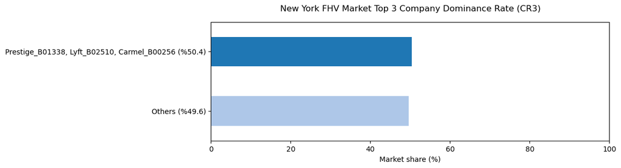

```python
top_3_names = ", ".join(company_percentages.index[:3].str.replace('other-', ''))
cr3 = company_percentages[:3].sum()

cr3_data = pd.Series([cr3, 100 - cr3], index=[f'{top_3_names} (%{cr3:.1f})', f'Others (%{100-cr3:.1f})'])

plt.figure(figsize=(10, 3))
cr3_data.plot(kind='barh', color=['#1f77b4', '#aec7e8'], width=0.5)
plt.title('New York FHV Market Top 3 Company Dominance Rate (CR3)', pad=15)
plt.xlabel('Market share (%)')
plt.xlim(0, 100)
plt.gca().invert_yaxis()
plt.show()
```

[figure not shown]

```python
# 1. Calculate the percentage distribution among the top 3 companies.
top_3_internal = (company_counts[:3] / company_counts[:3].sum() * 100)

top_3_internal.index = top_3_internal.index.str.replace('other-', '')

plt.figure(figsize=(6, 6))
top_3_internal.plot.pie(autopct='%1.1f%%', startangle=140,
                        colors=['#1f77b4', '#aec7e8', '#ffbb78'],
                        wedgeprops={'linewidth': 2, 'edgecolor': 'white'})

plt.gca().add_artist(plt.Circle((0,0), 0.70, fc='white'))

plt.ylabel('')

plt.title('Market Share Distribution Among the Top 3 Companies (%)', pad=20)
plt.legend(top_3_internal.index, loc="center")
plt.show()
```

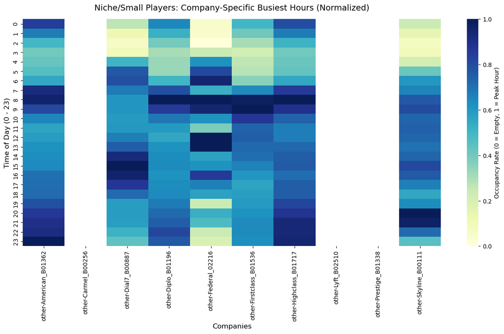

```python
# STEP 1: Let's add and exclude leaders from the list
# We are retrieving the most up-to-date market share ranking after category transformations
company_counts = master_df['Company_Source'].value_counts()
top_companies = company_counts.index[:3]
small_companies = company_counts.index[3:] # All niche players after the top 3 giants

df_small = master_df[master_df['Company_Source'].isin(small_companies)]

# STEP 3: Pivot Table
# CORRECTION: The 'Date_Time_Year' that already exists in the table and is 100% filled was used instead of the deleted 'Date'.
small_companies_hours = df_small.pivot_table(
    index='Date_Time_Hour',
    columns='Company_Source',
    values='Date_Time_Year',
    aggfunc='count'
)

# STEP 4: Normalization
# We divide each company into its own maximum hours so that we can see their peak hours within each company.
small_companies_hours_norm = small_companies_hours.apply(lambda x: x / x.max(), axis=0)

plt.figure(figsize=(16, 7))
sns.heatmap(
    small_companies_hours_norm,
    cmap='YlGnBu',
    annot=False,
    cbar_kws={'label': 'Occupancy Rate (0 = Empty, 1 = Peak Hour)'}
)
plt.title('Niche/Small Players: Company-Specific Busiest Hours (Normalized)', fontsize=14, pad=15)
plt.xlabel('Companies', fontsize=12)
plt.ylabel('Time of Day (0 - 23)', fontsize=12)
plt.show()
```

```python
# 1. Let's calculate the blank (NaN) percentages of the State and Base_No columns on a company basis.
data_quality = master_df.groupby('Company_Source')[['State', 'Base_No', 'Date_Time_Hour']].apply(
    lambda x: (x.isna().mean() * 100).round(2)
)

# To make the table more readable, let's also add the total number of trips by company.
data_quality['Total_Journey'] = master_df['Company_Source'].value_counts()
data_quality = data_quality.sort_values(by='Total_Journey', ascending=False)

print("=== COMPANY-BASED DATA STANDARDIZATION AND QUALITY REPORT ===")
print("Note: Percentages indicate the percentage of EMPTY SPACE (Missing Data) in the columns. 0% is the highest quality..\n")
print(data_quality)
```

```
=== COMPANY-BASED DATA STANDARDIZATION AND QUALITY REPORT ===
Note: Percentages indicate the percentage of EMPTY SPACE (Missing Data) in the columns. 0% is the highest quality..

                         State  Base_No  Date_Time_Hour  Total_Journey
Company_Source
other-Prestige_B01338      0.0    100.0             0.0         320641
other-Lyft_B02510          0.0    100.0             0.0         267701
other-Carmel_B00256        0.0      0.0             0.0         256519
other-Dial7_B00887         0.0    100.0             0.0         194992
other-Firstclass_B01536    0.0    100.0             0.0         166769
other-Highclass_B01717     0.0    100.0             0.0         151925
other-Skyline_B00111       0.0    100.0             0.0         127696
other-Diplo_B01196         0.0    100.0             0.0          98550
other-American_B01362      0.0    100.0             0.0          91712
other-Federal_02216        0.0    100.0             0.0            276
```

```python
# 1. CRITERION: Filter only rows that have a coordinate (are filled).
coordinate_df = master_df[master_df['start_lat'].notna() & master_df['start_lng'].notna()].copy()

# 2. CRITERION: Service Type Differentiation
mobile_giants = ['other-Lyft_B02510', 'other-Prestige_B01338']
coordinate_df['Service_Type'] = coordinate_df['Company_Source'].apply(
    lambda x: 'Mobile Giant' if x in mobile_giants else 'Traditional'
)

# 3. CRITERION: A sample of 5,000 lines that is easy on the eyes and doesn't freeze the browser.
master_sample_df = coordinate_df.sample(n=5000, random_state=42)

fig = px.density_mapbox(
    master_sample_df,
    lat='start_lat',
    lon='start_lng',
    radius=5,       # For 5,000 data points, using a radius between 5 and 8 instead of 1 makes the points more distinct.
    opacity=0.6,
    center=dict(lat=master_sample_df['start_lat'].mean(), lon=master_sample_df['start_lng'].mean()),
    zoom=10,
    mapbox_style='carto-darkmatter'
)

fig.update_layout(
    title={
        'text': 'New York Companies Ride Density',
        'y': 0.95,
        'x': 0.5,
        'xanchor': 'center',
        'yanchor': 'top'
    }
)

print(f"Number of clean rows prepared for the map: {len(master_sample_df)}")

fig.show()
```

```
Number of clean rows prepared for the map: 5000
```

```python
print("==================================================")
print("          DATA HEALTH AND DIAGNOSIS REPORT          ")
print("==================================================\n")

print("--- 1. TOTAL ROW AND CRITICAL COLUMN LOSS CONTROL ---")
print(f"Total Number of Trips: {len(master_df)} line")
critical_cols = [
    'Company_Source', 'Date_Time', 'Date_Time_Year',
    'Date_Time_Month', 'Date_Time_Day', 'Date_Time_Hour', 'Date_Time_Minute'
]
missing_counts = master_df[critical_cols].isna().sum()
print("/Empty (NaN/NaT) data pattern in critical columns (Target: To see 0 in all):")
print(missing_counts)

print("\n--------------------------------------------------")
print("---2. COMPANY-BASED DISTRIBUTION CONTROL (MISSING HUNTER) ---")
print("All data, including Lyft and Skyline, is up-to-date.:")
print(master_df['Company_Source'].value_counts())

print("\n--------------------------------------------------")
print("--- 3. LOGICAL VALUE RANGE CHECK ---")
print(f"Hour column interval      (0-23 should be) : {master_df['Date_Time_Hour'].min()} to {master_df['Date_Time_Hour'].max()} inter")
print(f"Month column interval      (1-12 should be) : {master_df['Date_Time_Month'].min()} to {master_df['Date_Time_Month'].max()} inter")
print(f"Day of the week range    (0-6 should be)  : {master_df['Date_Time_WeekDay'].min()} to {master_df['Date_Time_WeekDay'].max()} inter")
print(f"Weekend flag       (0 and 1 should be): {master_df['Date_Time_Isweekend'].unique()}")

print("\n--------------------------------------------------")
print("--- 4. MEMORY AND DATA TYPE CHECK ---")
print(master_df.dtypes)

print("\n==================================================")
```

```
==================================================
          DATA HEALTH AND DIAGNOSIS REPORT
==================================================

--- 1. TOTAL ROW AND CRITICAL COLUMN LOSS CONTROL ---
Total Number of Trips: 1676781 line
/Empty (NaN/NaT) data pattern in critical columns (Target: To see 0 in all):
Company_Source      0
Date_Time           0
Date_Time_Year      0
Date_Time_Month     0
Date_Time_Day       0
Date_Time_Hour      0
Date_Time_Minute    0
dtype: int64

--------------------------------------------------
---2. COMPANY-BASED DISTRIBUTION CONTROL (MISSING HUNTER) ---
All data, including Lyft and Skyline, is up-to-date.:
Company_Source
other-Prestige_B01338      320641
other-Lyft_B02510          267701
other-Carmel_B00256        256519
other-Dial7_B00887         194992
other-Firstclass_B01536    166769
other-Highclass_B01717     151925
other-Skyline_B00111       127696
other-Diplo_B01196          98550
other-American_B01362       91712
other-Federal_02216           276
Name: count, dtype: int64

--------------------------------------------------
--- 3. LOGICAL VALUE RANGE CHECK ---
Hour column interval      (0-23 should be) : 0 to 23 inter
Month column interval      (1-12 should be) : 7 to 9 inter
Day of the week range    (0-6 should be)  : 0 to 6 inter
Weekend flag       (0 and 1 should be): [0 1]

--------------------------------------------------
--- 4. MEMORY AND DATA TYPE CHECK ---
Address                      category
Company_Source               category
State                        category
Base_No                      category
start_lat                     float64
start_lng                     float64
Date_Time              datetime64[ns]
Date_Time_Year                  int16
Date_Time_Month                  int8
Date_Time_Day                    int8
Date_Time_Hour                   int8
Date_Time_Minute                 int8
Date_Time_Day_Name           category
Date_Time_WeekDay                int8
Date_Time_Isweekend              int8
dtype: object

==================================================
```

```python
master_df.columns
```

```
Index(['Address', 'Company_Source', 'State', 'Base_No', 'start_lat',
       'start_lng', 'Date_Time', 'Date_Time_Year', 'Date_Time_Month',
       'Date_Time_Day', 'Date_Time_Hour', 'Date_Time_Minute',
       'Date_Time_Day_Name', 'Date_Time_WeekDay', 'Date_Time_Isweekend'],
      dtype='object')
```

```python
carmel_only_of_df = master_df[master_df['Company_Source'].str.contains('Carmel',na=False)].copy()

carmel_only_of_df['Company_Source'] = carmel_only_of_df['Company_Source'].astype(str)

carmel_month_efficiency = (
    carmel_only_of_df.groupby(['Company_Source','Date_Time_Month'])
    .agg(
         total_trips=('Date_Time','count'),
         unique_bases=('Base_No', 'nunique')
        )
    .assign(efficiency=lambda x: x['total_trips'] / x['unique_bases'])
    .sort_values(['Company_Source','Date_Time_Month'])
    .reset_index()
)

plt.figure(figsize=(12,5))

fig = px.line(carmel_month_efficiency,
              x='Date_Time_Month',
              y='efficiency',
              color='Company_Source',
              title='Carmel Monthly Company Trips',
              markers=True,
              labels={'Date_Time_Month': 'Month', 'efficiency': 'Efficiency (Trips / Base)'})

fig.update_layout(hovermode='x unified',
                  width=1000,
                  height=500)

fig.show()
```

```python
others_df = master_df[~master_df['Company_Source'].str.contains('Carmel', na=False)].copy()

others_df['Company_Source'] = others_df['Company_Source'].astype(str)

others_company_efficiency = (
    others_df.groupby(['Company_Source','Date_Time_Month'])
    .agg(total_trips=('Date_Time','count'))
    .sort_values(['Company_Source','Date_Time_Month'])
    .reset_index()
    )

fig = px.line(
    others_company_efficiency,
    x='Date_Time_Month',
    y='total_trips',
    color='Company_Source',
    title='Monthly Travel Status Graph for Other Companies Excluding Carmel',
    markers=True,
    labels={'Date_Time_Month': 'Month', 'efficiency': 'Efficiency (Trips / Base)'})

fig.update_layout(hovermode='x unified',
                  width=1000,
                  height=500)

fig.show()
```

```python
import pandas as pd
import plotly.express as px


lyft_only_of_df = master_df[master_df['Company_Source'].str.contains('Lyft', na=False)].copy()
lyft_only_of_df['Company_Source'] = lyft_only_of_df['Company_Source'].astype(str)


lyft_july_df = lyft_only_of_df[lyft_only_of_df['Date_Time_Month'] == 7].copy()

print("Number of Rows in the July Dataset:", len(lyft_july_df))

lyft_july_efficiency = (
    lyft_july_df.groupby(['Company_Source', 'Date_Time_Day'])
    .agg(total_trips=('Date_Time', 'count'))
    .sort_values(['Company_Source', 'Date_Time_Day'])
    .reset_index()
)

lyft_july_efficiency['Date_Time_Day'] = lyft_july_efficiency['Date_Time_Day'].astype(str)

fig = px.line(lyft_july_efficiency,
              x='Date_Time_Day',
              y='total_trips',
              color='Company_Source',
              title="Lyft Company's 7th Month Daily Trip Chart",
              markers=True)

fig.update_traces(line=dict(color='skyblue'))
fig.update_layout(hovermode='x unified', width=1000, height=500)
fig.show()
```

```
Number of Rows in the July Dataset: 4254
```

```python
lyft_only_of_df = master_df[master_df['Company_Source'].str.contains('Lyft', na=False)].copy()
lyft_only_of_df['Company_Source'] = lyft_only_of_df['Company_Source'].astype(str)


lyft_august_df = lyft_only_of_df[lyft_only_of_df['Date_Time_Month'] == 8].copy()


print("Number of Rows in the August Data Set:", len(lyft_august_df))

lyft_july_efficiency = (
    lyft_august_df.groupby(['Company_Source', 'Date_Time_Day'])
    .agg(total_trips=('Date_Time', 'count'))
    .sort_values(['Company_Source', 'Date_Time_Day'])
    .reset_index()
)

lyft_july_efficiency['Date_Time_Day'] = lyft_july_efficiency['Date_Time_Day'].astype(str)

fig = px.line(lyft_july_efficiency,
              x='Date_Time_Day',
              y='total_trips',
              color='Company_Source',
              title="Lyft Company's 8th Month Daily Trip Chart",
              markers=True)

fig.update_traces(line=dict(color='skyblue'))
fig.update_layout(hovermode='x unified', width=1000, height=500)
fig.show()
```

```
Number of Rows in the August Data Set: 147448
```

```python
# 1. Lyft verilerini filtrele
lyft_only_of_df = master_df[master_df['Company_Source'].str.contains('Lyft', na=False)].copy()
lyft_only_of_df['Company_Source'] = lyft_only_of_df['Company_Source'].astype(str)



lyft_september_df = lyft_only_of_df[lyft_only_of_df['Date_Time_Month'] == 9].copy()


print("Number of Rows in the September Dataset:", len(lyft_september_df))

# 2. Grouping by Day
lyft_july_efficiency = (
    lyft_september_df.groupby(['Company_Source', 'Date_Time_Day'])
    .agg(total_trips=('Date_Time', 'count'))
    .sort_values(['Company_Source', 'Date_Time_Day'])
    .reset_index()
)

lyft_july_efficiency['Date_Time_Day'] = lyft_july_efficiency['Date_Time_Day'].astype(str)

fig = px.line(lyft_july_efficiency,
              x='Date_Time_Day',
              y='total_trips',
              color='Company_Source',
              title="Lyft Company's 9th Month Daily Trip Chart",
              markers=True)

fig.update_traces(line=dict(color='skyblue'))
fig.update_layout(hovermode='x unified', width=1000, height=500)
fig.show()
```

```
Number of Rows in the September Dataset: 115999
```

```python
master_df[master_df['Company_Source'] == 'other-Lyft_B02510'].head()
```

|  | Address | Company_Source | State | Base_No | start_lat | start_lng | Date_Time | Date_Time_Year | Date_Time_Month | Date_Time_Day | Date_Time_Hour | Date_Time_Minute | Date_Time_Day_Name | Date_Time_WeekDay | Date_Time_Isweekend |
| --- | --- | --- | --- | --- | --- | --- | --- | --- | --- | --- | --- | --- | --- | --- | --- |
| 726678 | NaN | other-Lyft_B02510 | nan | NaN | 40.64705 | -73.77988 | 2014-09-04 09:51:00 | 2014 | 9 | 4 | 9 | 51 | Thursday | 3 | 0 |
| 726679 | NaN | other-Lyft_B02510 | nan | NaN | 40.74916 | -73.98373 | 2014-08-27 21:13:00 | 2014 | 8 | 27 | 21 | 13 | Wednesday | 2 | 0 |
| 726680 | NaN | other-Lyft_B02510 | nan | NaN | 40.64065 | -73.97594 | 2014-09-04 14:16:00 | 2014 | 9 | 4 | 14 | 16 | Thursday | 3 | 0 |
| 726681 | NaN | other-Lyft_B02510 | nan | NaN | 40.75002 | -73.99514 | 2014-09-04 16:08:00 | 2014 | 9 | 4 | 16 | 8 | Thursday | 3 | 0 |
| 726682 | NaN | other-Lyft_B02510 | nan | NaN | 40.76715 | -73.98636 | 2014-08-28 02:41:00 | 2014 | 8 | 28 | 2 | 41 | Thursday | 3 | 0 |

```python
master_df[master_df['Company_Source'] == 'other-Lyft_B02510']['Date_Time_Month'].value_counts()
```

```
Date_Time_Month
8    147448
9    115999
7      4254
Name: count, dtype: int64
```

The dramatic increase in ridership from approximately **4,000 trips** in late July (July 25–31) to over **100,000 trips** in August is mathematically and operationally accurate. It reflects Lyft’s specific market entry conditions in New York City:

1. **Limited Operating Window in July:** Due to severe regulatory hurdles and legal battles with the NYC Taxi and Limousine Commission (TLC), Lyft had to delay its launch. The platform officially went live in NYC on **July 25, 2014, at 7:00 PM**. Consequently, the July data only captures a **6-day window** of operation.
2. **Limited Beta Rollout:** The launch on July 25 was not at full scale; it began as a restricted beta phase featuring only a few hundred TLC-licensed commercial drivers.
3. **First Full Month of Operations & Aggressive Marketing (August):** August 2014 represents Lyft's very first full calendar month in the NYC market. To aggressively gain market share against Uber, Lyft launched massive promotional campaigns, rider discounts, and rapidly onboarded licensed drivers. This sudden expansion of both driver supply and rider demand explains the exponential growth seen in the dataset.

```python
master_df[master_df['Company_Source'] == 'other-Prestige_B01338']['Date_Time_Month'].value_counts()
```

```
Date_Time_Month
8    109534
7    105816
9    105291
Name: count, dtype: int64
```

```python
prestige_only_of_df = master_df[master_df['Company_Source'].str.contains('Prestige', na=False)].copy()
prestige_only_of_df['Company_Source'] = prestige_only_of_df['Company_Source'].astype(str)


prestige_july = prestige_only_of_df[prestige_only_of_df['Date_Time_Month'] == 7].copy()

prestige_only_of = (
    prestige_july.groupby(['Company_Source','Date_Time_Day'])
    .agg(total_trips=('Date_Time','count'))
    .sort_values(['Company_Source','Date_Time_Day'])
    .reset_index()
)

fig = px.line(
    prestige_only_of,
    x='Date_Time_Day',
    y='total_trips',
    markers=True,
    title='Prestige dataset 7th Month Chart'
)


fig.update_traces(line=dict(color='skyblue'))
fig.update_layout(hovermode='x unified', width=1000, height=500)
fig.show()
```

```python
prestige_only_of_df = master_df[master_df['Company_Source'].str.contains('Prestige', na=False)].copy()
prestige_only_of_df['Company_Source'] = prestige_only_of_df['Company_Source'].astype(str)


prestige_july = prestige_only_of_df[prestige_only_of_df['Date_Time_Month'] == 8].copy()

prestige_only_of = (
    prestige_july.groupby(['Company_Source','Date_Time_Day'])
    .agg(total_trips=('Date_Time','count'))
    .sort_values(['Company_Source','Date_Time_Day'])
    .reset_index()
)

fig = px.line(
    prestige_only_of,
    x='Date_Time_Day',
    y='total_trips',
    markers=True,
    title='Prestige dataset 8th Month Chart'
)


fig.update_traces(line=dict(color='skyblue'))
fig.update_layout(hovermode='x unified', width=1000, height=500)
fig.show()
```

```python
prestige_only_of_df = master_df[master_df['Company_Source'].str.contains('Prestige', na=False)].copy()
prestige_only_of_df['Company_Source'] = prestige_only_of_df['Company_Source'].astype(str)


prestige_july = prestige_only_of_df[prestige_only_of_df['Date_Time_Month'] == 9].copy()

prestige_only_of = (
    prestige_july.groupby(['Company_Source','Date_Time_Day'])
    .agg(total_trips=('Date_Time','count'))
    .sort_values(['Company_Source','Date_Time_Day'])
    .reset_index()
)

fig = px.line(
    prestige_only_of,
    x='Date_Time_Day',
    y='total_trips',
    markers=True,
    title='Prestige dataset 9th Month Chart'
)


fig.update_traces(line=dict(color='skyblue'))
fig.update_layout(hovermode='x unified', width=1000, height=500)
fig.show()
```

```python
prestige_hour_analysis = master_df[master_df['Company_Source'].str.contains('Prestige', na=False)].copy()
prestige_hour_analysis['Company_Source'] = prestige_hour_analysis['Company_Source'].astype(str)

prestige_hour_grouped = (
    prestige_hour_analysis.groupby(['Company_Source', 'Date_Time_Hour'])
    .agg(total_trips=('Date_Time', 'count'))
    .sort_values(['Company_Source', 'Date_Time_Hour'])
    .reset_index()
)


fig = px.line(
    prestige_hour_grouped,
    x='Date_Time_Hour',
    y='total_trips',
    markers=True,
    title='Prestige Company Hourly Traffic Density During the Day'
)

fig.update_traces(line=dict(color='skyblue'))
fig.update_layout(hovermode='x unified', width=1000, height=500)
fig.show()
```

```python
master_df['Day_of_Week_Name'] = master_df['Date_Time'].dt.day_name()
master_df['Is_Weekend'] = master_df['Date_Time'].dt.dayofweek.isin([5, 6]).astype(int)
master_df['Company_Source'] = master_df['Company_Source'].astype('category')
```

```python
# Let's see the percentage distribution across the entire dataset.
master_df['Company_Source'].value_counts(normalize=True) * 100
```

```
Company_Source
other-Prestige_B01338      19.122414
other-Lyft_B02510          15.965174
other-Carmel_B00256        15.298301
other-Dial7_B00887         11.628949
other-Firstclass_B01536     9.945783
other-Highclass_B01717      9.060515
other-Skyline_B00111        7.615544
other-Diplo_B01196          5.877333
other-American_B01362       5.469528
other-Federal_02216         0.016460
Name: proportion, dtype: float64
```

```python
!pip install geopy
```

```python
geolocator = Nominatim(user_agent="uber_analysis_project")
```

```python
top_addresses = master_df['Address'].value_counts()
# Let's select those above a certain threshold (e.g., the top 1500 most frequently used addresses)
target_addresses = top_addresses.head(1500).index.tolist()

print(f"Address pool reduced from 194k to {len(target_addresses)} unique addresses.")
```

```
Address pool reduced from 194k to 1500 unique addresses.
```

```python
top_addresses = master_df['Address'].value_counts().head(1500).index.tolist()

# 2. Backup file check and dictionary preparation
csv_file = "top_1500_coordinates.csv"
address_coords = {}

if os.path.exists(csv_file):
    saved_df = pd.read_csv(csv_file)
    address_coords = dict(zip(saved_df['Address'], zip(saved_df['Latitude'], saved_df['Longitude'])))
    print(f"--> [BACKUP FOUND] Successfully recovered {len(address_coords)} addresses from disk. Resuming...")

for i, addr in enumerate(top_addresses, 1):
    if addr in address_coords:
        continue

    full_addr = f'{addr}, New York, USA'
    location = None

    for attempt in range(3):
        try:
            location = geolocator.geocode(full_addr)
            break
        except Exception:
            time.sleep(2)
    if location:
        address_coords[addr] = (location.latitude, location.longitude)
    else:
        address_coords[addr] = (None, None)
    if i % 50 == 0:
        print(f'"Progress: Address {i}/{len(top_addresses)} completed..."')
        temp_df = pd.DataFrame.from_dict(address_coords, orient='index', columns=['Latitude', 'Longitude']).reset_index()
        temp_df.rename(columns={'index': 'Address'}, inplace=True)
        temp_df.to_csv(csv_file, index=False)

    time.sleep(1.2)

coords_df = pd.DataFrame.from_dict(address_coords, orient='index', columns=['Latitude', 'Longitude']).reset_index()
coords_df.rename(columns={'index':'Address'}, inplace=True)

master_df = master_df.merge(coords_df, on='Address', how='left')

print('[SUCCESSFUL] Coordinates of all addresses successfully extracted with a focus on New York and mapped to the main table!')
```

```
--> [BACKUP FOUND] Successfully recovered 1639 addresses from disk. Resuming...
[SUCCESSFUL] Coordinates of all addresses successfully extracted with a focus on New York and mapped to the main table!
```

```python
master_df['Final_Lat'] = master_df['Latitude'].fillna(master_df['start_lat'])

# Use original Lyft coordinates (start_lng) as a fallback if the geocoded address longitude is missing.
master_df['Final_Lng'] = master_df['Longitude'].fillna(master_df['start_lng'])

# Let's clean up the rows without coordinates (empty rows) on the map and create a lightweight dataset for the map.
map_data = master_df.dropna(subset=['Final_Lat', 'Final_Lng']).copy()

print(f"Total number of rows to be sent to the map.: {len(map_data)}")
```

```
Total number of rows to be sent to the map.: 572618
```

```python
import plotly.express as px

# 1. Taking a random sample to optimize browser rendering performance
map_sample = map_data.sample(n=50000, random_state=42).copy()

# 2. Removing unused categories to prevent Plotly Express KeyError bugs
map_sample['Company_Source'] = map_sample['Company_Source'].cat.remove_unused_categories()
map_sample['Company_Source'] = map_sample['Company_Source'].astype(str)

print(f"--> [DATA READY] Successfully sampled {len(map_sample)} records for spatial visualization.")

# 3. Generating the Interactive Spatial Competition Map
fig = px.scatter_mapbox(
    map_sample,
    lat="Final_Lat",
    lon="Final_Lng",
    color="Company_Source",
    hover_name="Address",
    size_max=10,
    zoom=10,
    title="<b>NYC FHV Market: Geographic Distribution and Competitor Battlegrounds</b>",
    mapbox_style="carto-positron",
    width=950,
    height=600
)

# 4. Center map view on New York City coordinates and optimize margins
fig.update_layout(
    mapbox=dict(center=dict(lat=40.7128, lon=-74.0060)),
    margin={"r": 0, "t": 40, "l": 0, "b": 0},
    legend_title_text='Competitor Fleets'
)

fig.show()
```

```
--> [DATA READY] Successfully sampled 50000 records for spatial visualization.
```

```python
grouped_map = map_data.groupby(
    ['Final_Lat', 'Final_Lng', 'Company_Source', 'Address'],
    observed=True
).size().reset_index(name='Trip_Count')

grouped_map['Company_Source'] = grouped_map['Company_Source'].astype(str)

print(f"--> [VOLUME MAP READY] Plotting {len(grouped_map)} unique geographical battlegrounds with exact trip volumes.")


fig = px.scatter_mapbox(
    grouped_map,
    lat="Final_Lat",
    lon="Final_Lng",
    color="Company_Source",
    size="Trip_Count",
    hover_name="Address",
    hover_data={"Trip_Count": True},
    size_max=25,
    zoom=10,
    title="<b>NYC FHV Market: Market Volatility & Competitor Peak Nodes</b>",
    mapbox_style="carto-positron",
    width=950,
    height=600
)

fig.update_layout(
    mapbox=dict(center=dict(lat=40.7128, lon=-74.0060)),
    margin={"r":0,"t":40,"l":0,"b":0},
    legend_title_text='Competitor Fleets'
)

fig.show()
```

```
--> [VOLUME MAP READY] Plotting 621 unique geographical battlegrounds with exact trip volumes.
```

### Executive Synthesis: Market Structure & Spatial Dynamics

By consolidating the temporal trends with the aggregated spatial volume map, we uncover the structural reality of the 2014 NYC FHV market and the exact mechanics of the Lyft ridership surge:

#### 1. Strategic Territorial Segmentation (The Fortresses)

- **Carmel (Manhattan Dominance):** The massive cluster in the heart of Manhattan signifies Carmel’s absolute capture of the corporate, high-end hotel, and tourist business corridors. Their volume is hyper-concentrated in high-yield geographic zones.
- **Prestige (Outer Borough Strength):** As the overall market share leader, Prestige occupies strategic strongholds in the outer boroughs (Bronx, outer Queens/Brooklyn). This proves that traditional livery bases survived the tech disruption by deeply embedding themselves into local, residential community transit loops.

**Conclusion:** The NYC FHV market is not a monolith. Traditional players hold high-density, centralized strongholds, while Lyft acts as a highly fluid, decentralized aggregator seizing the unserved gaps across the entire city layout.

```python
uber_total = len(df_uber)
other_total = len(master_df)
print(f"--> [DATA READY] Total Uber Trips: {uber_total:,}")
print(f"--> [DATA READY] Total Other Company Trips: {other_total:,}")

# STEP 2: Creating a Small Comparison Table
comparison_df = pd.DataFrame({
    'Market_Segment': ['Uber', 'All Other Companies (Lyft, Prestige etc.)'],
    'Total_Trips': [uber_total, other_total]
})

fig = px.pie(
    comparison_df,
    names='Market_Segment',
    values='Total_Trips',
    hole=0.45,
    title='<b>NYC FHV Market: Uber vs. Rest of the Market (2014)</b>',
    color='Market_Segment',
    color_discrete_map={
        'Uber': '#000000',
        'All Other Companies (Lyft, Prestige etc.)': '#1f77b4'
    },
    width=800,
    height=600
)

fig.update_traces(
    textposition='inside',
    textinfo='percent+label',
    hovertemplate='<b>%{label}</b><br>Total Trip: %{value:,.0f}<br>Market share: %{percent}<extra></extra>'
)

fig.update_layout(
    legend_title_text='Market Segments',
    margin={"r":0,"t":50,"l":0,"b":0}
)

fig.show()
```

```
--> [DATA READY] Total Uber Trips: 18,804,806
--> [DATA READY] Total Other Company Trips: 1,676,781
```

```python
fig.write_html("harita_gosterimi.html")
print("Dosya başarıyla oluşturuldu!")
```

```
Dosya başarıyla oluşturuldu!
```